# 2026 Summer Institute on Longitudinal Data Analysis

Prepared by Kristine Marceau and Jennifer Hu

2026-07-06

# Overview

This file includes the data cleaning code for ABCD variables that can be used as examples in the Methodology Center Summer Institute on Longitudinal Data Analysis. For each section below, the code is organized by topic/phenotype (level 1 header), a description of the datasets and variables used according to ABCD documentation (level 2 header), the items and descriptions from each dataset are provided under the dataset name (level 3 header). As applicable, the scored phenotypes will be listed (level 4 headers). Finally, code for cleaning and creating summary variables are also provided (level 2 headers).

**Please note that we did not correct any distributions/outliers - this is up to each instructor.**

Data documentation can be found here: https://docs.abcdstudy.org/latest/documentation/curation/structure.html

Load in packages and data (Hidden)

```r
#clear working memory, if needed
rm(list = ls())

# Data manipulation
library(tidyverse)      # dplyr, ggplot2, readr, tidyr, tibble,
                        # purrr, stringr, forcats
# Reading ABCD data
library(arrow)          # read_parquet()

# Dates and times
library(lubridate)      # Date/time handling (visit dates)

# Descriptive statistics
library(psych)          # describe()
library(moments)        # skewness(), kurtosis()
                        # (used inside the plotting helper functions)

# Tables
library(kableExtra)     # kbl(), kable_minimal(),
                        # kable_styling(), collapse_rows(),
                        # scroll_box()

# Custom plotting functions
source("https://raw.githubusercontent.com/tdmize/Rfunctions/main/Viz_helper_functions.R")
```

# Codebook by Construct:

[output not shown]

## Note on Session_id

In ABCD 7.0, session_id includes timepoints with S (screener), A (annual assessment), and M (midpoint assessment). We maintain only sessions from the annual assessment (i.e., ses-#A).

## Note on Viz Helper Functions

Available visualization helper functions:

**plot_nominal()**

*Key arguments:* data = data frame var = categorical variable to plot title = optional plot title xlab = optional x-axis label ylab = optional y-axis label (default = “Count”) show_percent = whether to display percentages above bars (default = TRUE)

**plot_distribution()**

Creates a histogram for a single numeric variable and displays N, mean, SD, skewness, and kurtosis, along with reference lines at the mean, ±1 SD, and ±3 SD.

*Key arguments:* data = data frame var = numeric variable to plot title = optional plot title xlab = optional x-axis label annotate_x = optional x-position for summary statistics

**plot_distribution_by_time()**

Creates faceted histograms by timepoint (or another grouping variable), with group-specific summary statistics and reference lines calculated separately within each facet.

*Key arguments:* data = data frame var = numeric variable to plot time_var = grouping/facet variable title = optional plot title xlab = optional x-axis label annotate_x = optional x-position for summary statistics

**plot_longitudinal_subset()**

Creates a longitudinal “spaghetti plot” for a random subset of participants, families, or other repeated-measures units, with an overall LOESS trend line.

*Key arguments:* data = long-format data frame var = outcome variable time_var = time variable id_var = participant/family ID sample_n = number of IDs to sample (default = 100) seed = random seed for reproducibility title, xlab, ylab = optional labels

**plot_cormat_heatmap()**

Creates an upper-triangle Pearson correlation heatmap for a set of numeric variables, displaying the correlation coefficient in each cell.

*Key arguments:* wide_subset = data frame containing variables of interest

Load in datasets

# Demographic Variables

## Dataset(s) & Variables Used Note:

This section creates demographic, family structure, and visit-level variables from ABCD parent-report and administrative datasets. These variables include caregiver relationship to the child, caregiver marital status, household size and composition, the child’s time in another household, child race/ethnicity and sex assigned at birth, family and birth-event identifiers, family relationship structure, youth age at visit, and visit date/time.

**ab_p_demo**

*ab_p_demo__relation_001* (formerly demo_prim & demo_prim_l): Relationship to the participant: You are the… 1 = Child’s biological mother, 2 = Child’s biological father, 3 = adoptive parent, 4 = Child’s custodial parent, 5 = other

*ab_p_demo__marital__slf_001* (formerly demo_prnt_marital_v2 & demo_prnt_marital_v2_l) 1 = Married, 2 = Widowed, 3 = Divorced, 4 = Separated, 5 = Never married, 6 = Living with partner, 777 = decline to answer

*ab_p_demo__roster_001* (formerly demo_roster_v2 & demo_roster_v2_l): How many people are living at your address?

*ab_p_demo__roster_002 through ab_p_demo__roster_015* (formerly fam_roster_2c_v2 through fam_roster_15c_v2 & fam_roster_2c_v2_l through fam_roster_15c_v2_l): Person #2 through Person #15 who lives at your address, relationship to you. 1 = Spouse; 2 = child-in-law; 3 = Biological child; 4 = Other relative; 5 = Adopted child; 6 = Roomer or boarder; 7 = Stepchild; 8 = Housemate or roommate; 9 = sibling; 10 = Unmarried partner; 11 = parent; 12 = Foster child; 13 = Grandchild; 14 = Other nonrelative; 15 = Parent-in-law

*ab_p_demo__child__time_001* (formerly demo_child_time_v2 & demo_child_time_v2_l): Is there another household in which the child spends a significant amount of time? 1 = Yes; 0 = No; 777 = Declined to answer

*ab_p_demo__child__time_001__01* (formerly demo_child_time2_v2 & demo_child_time2_v2_l): About how much time per week does the child spend at this other household?

*ab_p_demo__child__time_001__02* (formerly demo_child_time3_v2 & demo_child_time3_v2_l): Who is the best person to contact about that household? 1 = other biological parent; 2 = step mother; 3 = step father; 4 = grandmother; 5 = grandfather; 6 = aunt; 7 = uncle; 8 = other

**ab_g_stc**

*ab_g_stc__cohort_acsps* Cohort description: Imputed raked propensity weight - The raked propensity weight merges the ACS and ABCD baseline data (with missing data imputed), estimates the propensity model, computes and scales/trims the propensity weights and finally rakes the scaled weights to final ACS control totals by age, sex and race/ethnicity [Based on baseline demographics data]

*ab_g_stc__cohort_race__nih*: Race (NIH classification reporting 7 levels) [Based on baseline response; missingness filled in from longitudinal responses]

*ab_g_stc__cohort_sex* (formerly demo_sex_v2 in abcd_p_demo): Parent reported sex assigned at birth. 1=Male, 2=female

*ab_g_stc__design_id__fam* (formerly rel_family_id): Design/nesting: Family ID - Participants belonging to the same family share a family ID (derived based on caregiver information)

*ab_g_stc__design_id__birth* (formerly rel_birth_id): Design/nesting: Birth event ID - Participants from the same family who were born together share a birth event ID (derived based on unique birthdates)

*ab_g_stc__design_famrel* (formerly rel_relationship): Design/nesting: Relationship of the participant in their family

**ab_g_dyn**

*ab_g_dyn__visit_age* (formerly demo_brthdat_v2 & demo_brthdat_v2_l): Youth’s age at the start of the event

*ab_g_dyn__visit_dtt* (formerly interview_date): Visit information: Date and time at the start of the visit

*ab_g_dyn__design_site*: Study Site

## Data Cleaning & Variable Creation

```r
#Subset demo dataset to variables of interest
s.demo <- c("participant_id","session_id", "ab_p_demo__relation_001","ab_p_demo__marital__slf_001", "ab_p_demo__roster_001", "ab_p_demo__roster_002", "ab_p_demo__roster_003", "ab_p_demo__roster_004", "ab_p_demo__roster_005", "ab_p_demo__roster_006", "ab_p_demo__roster_007", "ab_p_demo__roster_008", "ab_p_demo__roster_009", "ab_p_demo__roster_010", "ab_p_demo__roster_011", "ab_p_demo__roster_012", "ab_p_demo__roster_013", "ab_p_demo__roster_014", "ab_p_demo__roster_015", "ab_p_demo__child__time_001", "ab_p_demo__child__time_001__01", "ab_p_demo__child__time_001__02")
demo_subset <- demo[s.demo]

#Subset dyn dataset to variables of interest
s.dyn <- c("participant_id", "session_id", "ab_g_dyn__visit_age", "ab_g_dyn__visit_dtt","ab_g_dyn__design_site")
dyn_subset <- dyn[s.dyn]

#Subset stc dataset to variables of interest
s.stc <- c("participant_id", "ab_g_stc__cohort_ethnrace__leg", "ab_g_stc__cohort_race__nih","ab_g_stc__cohort_acsps", "ab_g_stc__cohort_sex", "ab_g_stc__design_id__fam", "ab_g_stc__design_id__birth", "ab_g_stc__design_famrel")
stc_subset <- stc[s.stc]


#merge select var datasets for demographics of demo_subset, stc_subset, & dyn_subset
demo_datavars <- list(demo_subset, dyn_subset)
demo_merged <- Reduce(function(x, y) merge(x, y, by = c("participant_id","session_id"), all = TRUE), demo_datavars)

#As stc doesn't have a session_id var, merge only by participant_id
#merge dataframes
demo_m <- merge(demo_merged, stc_subset, by=c("participant_id"), all = TRUE)

#create multigenerational home variable If parent (11) or grandchild (13) or parent-in-law (15) selected, then 1 (i.e., parent/guardian and child live with ), all else 0.
demo_m <- demo_m %>%
  mutate(multigen = case_when(
    (ab_p_demo__roster_002 == 11 | ab_p_demo__roster_002 == 13 | ab_p_demo__roster_002 == 15) ~ 1,
    (ab_p_demo__roster_003 == 11 | ab_p_demo__roster_003 == 13 | ab_p_demo__roster_003 == 15) ~ 1,
    (ab_p_demo__roster_004 == 11 | ab_p_demo__roster_004 == 13 | ab_p_demo__roster_004 == 15) ~ 1,
    (ab_p_demo__roster_005 == 11 | ab_p_demo__roster_005 == 13 | ab_p_demo__roster_005 == 15) ~ 1,
    (ab_p_demo__roster_006 == 11 | ab_p_demo__roster_006 == 13 | ab_p_demo__roster_006 == 15) ~ 1,
    (ab_p_demo__roster_007 == 11 | ab_p_demo__roster_007 == 13 | ab_p_demo__roster_007 == 15) ~ 1,
    (ab_p_demo__roster_008 == 11 | ab_p_demo__roster_008 == 13 | ab_p_demo__roster_008 == 15) ~ 1,
    (ab_p_demo__roster_009 == 11 | ab_p_demo__roster_009 == 13 | ab_p_demo__roster_009 == 15) ~ 1,
    (ab_p_demo__roster_010 == 11 | ab_p_demo__roster_010 == 13 | ab_p_demo__roster_010 == 15) ~ 1,
    (ab_p_demo__roster_011 == 11 | ab_p_demo__roster_011 == 13 | ab_p_demo__roster_011 == 15) ~ 1,
    (ab_p_demo__roster_012 == 11 | ab_p_demo__roster_012 == 13 | ab_p_demo__roster_012 == 15) ~ 1,
    (ab_p_demo__roster_013 == 11 | ab_p_demo__roster_013 == 13 | ab_p_demo__roster_013 == 15) ~ 1,
    (ab_p_demo__roster_014 == 11 | ab_p_demo__roster_014 == 13 | ab_p_demo__roster_014 == 15) ~ 1,
    (ab_p_demo__roster_015 == 11 | ab_p_demo__roster_015 == 13 | ab_p_demo__roster_015 == 15) ~ 1,
    TRUE ~ 0))

demo_m <- demo_m %>%
  mutate(housepop = ab_p_demo__roster_001)

#Drop roster variables that are not longer needed
s.demor <- c("participant_id", "session_id", "ab_g_dyn__visit_dtt", "ab_g_dyn__visit_age", "ab_p_demo__relation_001", "ab_p_demo__marital__slf_001", "multigen", "ab_p_demo__child__time_001", "ab_p_demo__child__time_001__01", "ab_p_demo__child__time_001__02", "ab_g_stc__cohort_ethnrace__leg", "ab_g_stc__cohort_race__nih", "ab_g_stc__cohort_sex", "ab_g_stc__design_id__fam", "ab_g_stc__design_id__birth", "ab_g_stc__design_famrel","housepop","ab_g_dyn__design_site")
demo_mf <- demo_m[s.demor]
```

## Descriptive Statistics

Demographic Summary Statistics

|  | vars | n | mean | sd | median | trimmed | mad | min | max | range | skew | kurtosis | se |
| --- | --- | --- | --- | --- | --- | --- | --- | --- | --- | --- | --- | --- | --- |
| participant_id | 1 | 11860 | 5930.5000000 | 3423.8314308 | 5930.500000 | 5930.500000 | 4395.9090000 | 1.000000 | 11860.00000 | 11859.000000 | 0.0000000 | -1.2003035 | 31.4390946 |
| ab_g_dyn__visit_age_ses-00A | 2 | 11860 | 9.9557075 | 0.6247159 | 9.936986 | 9.947541 | 0.8286312 | 8.315069 | 11.30685 | 2.991781 | 0.0648992 | -1.2648448 | 0.0057364 |
| ab_g_dyn__visit_age_ses-01A | 3 | 11220 | 10.9643706 | 0.6435310 | 10.947945 | 10.957434 | 0.8326932 | 9.331507 | 12.44658 | 3.115069 | 0.0630424 | -1.1884752 | 0.0060754 |
| ab_g_dyn__visit_age_ses-02A | 4 | 10989 | 12.0681151 | 0.6695132 | 12.054645 | 12.059175 | 0.8126055 | 10.230137 | 13.97268 | 3.742541 | 0.1154171 | -0.9164784 | 0.0063868 |
| ab_g_dyn__visit_age_ses-03A | 5 | 10516 | 12.9599656 | 0.6489550 | 12.942623 | 12.952206 | 0.8004309 | 11.371585 | 15.30137 | 3.929785 | 0.0869952 | -1.0089907 | 0.0063283 |
| ab_g_dyn__visit_age_ses-04A | 6 | 9792 | 14.1691348 | 0.7112715 | 14.164384 | 14.158212 | 0.8408170 | 12.446575 | 16.57534 | 4.128767 | 0.1117322 | -0.8199170 | 0.0071879 |
| ab_g_dyn__visit_age_ses-05A | 7 | 9050 | 15.0774561 | 0.6707972 | 15.057377 | 15.071540 | 0.8326932 | 13.498630 | 16.68493 | 3.186301 | 0.0688330 | -1.0541659 | 0.0070513 |
| ab_g_dyn__visit_age_ses-06A | 8 | 9539 | 16.0565980 | 0.6824517 | 16.038356 | 16.045824 | 0.8383643 | 13.635616 | 18.03562 | 4.400000 | 0.1242967 | -0.8977898 | 0.0069875 |
| ab_g_dyn__visit_age_ses-07A | 9 | 8564 | 16.9398232 | 0.6628045 | 16.920548 | 16.931152 | 0.8367551 | 15.393443 | 18.54521 | 3.151763 | 0.0895129 | -1.0632795 | 0.0071622 |
| ab_p_demo__relation_001_ses-00A | 10 | 11860 | 1.2313659 | 0.6703540 | 1.000000 | 1.058495 | 0.0000000 | 1.000000 | 5.00000 | 4.000000 | 3.6885694 | 14.9435804 | 0.0061555 |
| ab_p_demo__relation_001_ses-01A | 11 | 11209 | 1.2367740 | 0.6618492 | 1.000000 | 1.069908 | 0.0000000 | 1.000000 | 5.00000 | 4.000000 | 3.6138078 | 14.6364736 | 0.0062514 |
| ab_p_demo__relation_001_ses-02A | 12 | 10917 | 1.2332143 | 0.6564669 | 1.000000 | 1.066171 | 0.0000000 | 1.000000 | 5.00000 | 4.000000 | 3.6070556 | 14.5362868 | 0.0062829 |
| ab_p_demo__relation_001_ses-03A | 13 | 10248 | 1.2169204 | 0.6425577 | 1.000000 | 1.049634 | 0.0000000 | 1.000000 | 5.00000 | 4.000000 | 3.7741673 | 15.8441963 | 0.0063474 |
| ab_p_demo__relation_001_ses-04A | 14 | 9547 | 1.2164031 | 0.6395800 | 1.000000 | 1.049876 | 0.0000000 | 1.000000 | 5.00000 | 4.000000 | 3.7658248 | 15.8165240 | 0.0065458 |
| ab_p_demo__relation_001_ses-05A | 15 | 8814 | 1.2140912 | 0.6219454 | 1.000000 | 1.054736 | 0.0000000 | 1.000000 | 5.00000 | 4.000000 | 3.7581457 | 16.0752402 | 0.0066247 |
| ab_p_demo__relation_001_ses-06A | 16 | 9388 | 1.2227311 | 0.6353519 | 1.000000 | 1.060703 | 0.0000000 | 1.000000 | 5.00000 | 4.000000 | 3.6686566 | 15.1974571 | 0.0065573 |
| ab_p_demo__relation_001_ses-07A | 17 | 8395 | 1.2203693 | 0.6321462 | 1.000000 | 1.060146 | 0.0000000 | 1.000000 | 5.00000 | 4.000000 | 3.7368326 | 15.8989782 | 0.0068993 |
| ab_p_demo__marital__slf_001_ses-00A | 18 | 11858 | 2.1367010 | 1.7703481 | 1.000000 | 1.828836 | 0.0000000 | 1.000000 | 7.00000 | 6.000000 | 1.1649163 | -0.2253563 | 0.0162575 |
| ab_p_demo__marital__slf_001_ses-01A | 19 | 11209 | 2.0986707 | 1.7476626 | 1.000000 | 1.780577 | 0.0000000 | 1.000000 | 7.00000 | 6.000000 | 1.2253786 | -0.0636046 | 0.0165072 |
| ab_p_demo__marital__slf_001_ses-02A | 20 | 10917 | 2.1147751 | 1.7539462 | 1.000000 | 1.795764 | 0.0000000 | 1.000000 | 7.00000 | 6.000000 | 1.2110967 | -0.0869152 | 0.0167867 |
| ab_p_demo__marital__slf_001_ses-03A | 21 | 10259 | 2.0499074 | 1.7087747 | 1.000000 | 1.722987 | 0.0000000 | 1.000000 | 7.00000 | 6.000000 | 1.3033038 | 0.1807260 | 0.0168707 |
| ab_p_demo__marital__slf_001_ses-04A | 22 | 9552 | 2.0743300 | 1.7185246 | 1.000000 | 1.750720 | 0.0000000 | 1.000000 | 7.00000 | 6.000000 | 1.2719532 | 0.1058290 | 0.0175836 |
| ab_p_demo__marital__slf_001_ses-05A | 23 | 8818 | 2.0919710 | 1.7225105 | 1.000000 | 1.772959 | 0.0000000 | 1.000000 | 7.00000 | 6.000000 | 1.2498841 | 0.0727691 | 0.0183433 |
| ab_p_demo__marital__slf_001_ses-06A | 24 | 9388 | 2.0880912 | 1.6757550 | 1.000000 | 1.788072 | 0.0000000 | 1.000000 | 7.00000 | 6.000000 | 1.2123787 | 0.0182970 | 0.0172951 |
| ab_p_demo__marital__slf_001_ses-07A | 25 | 8397 | 2.0421579 | 1.6541442 | 1.000000 | 1.727787 | 0.0000000 | 1.000000 | 7.00000 | 6.000000 | 1.3023939 | 0.2935966 | 0.0180514 |
| multigen_ses-00A | 26 | 11860 | 0.0934233 | 0.2910369 | 0.000000 | 0.000000 | 0.0000000 | 0.000000 | 1.00000 | 1.000000 | 2.7937514 | 5.8055366 | 0.0026724 |
| multigen_ses-01A | 27 | 11220 | 0.0857398 | 0.2799918 | 0.000000 | 0.000000 | 0.0000000 | 0.000000 | 1.00000 | 1.000000 | 2.9588242 | 6.7552430 | 0.0026433 |
| multigen_ses-02A | 28 | 10989 | 0.0854491 | 0.2795615 | 0.000000 | 0.000000 | 0.0000000 | 0.000000 | 1.00000 | 1.000000 | 2.9654523 | 6.7945254 | 0.0026668 |
| multigen_ses-03A | 29 | 10516 | 0.0781666 | 0.2684463 | 0.000000 | 0.000000 | 0.0000000 | 0.000000 | 1.00000 | 1.000000 | 3.1424774 | 7.8759133 | 0.0026178 |
| multigen_ses-04A | 30 | 9792 | 0.0762868 | 0.2654699 | 0.000000 | 0.000000 | 0.0000000 | 0.000000 | 1.00000 | 1.000000 | 3.1918488 | 8.1887352 | 0.0026827 |
| multigen_ses-05A | 31 | 9050 | 0.0781215 | 0.2683776 | 0.000000 | 0.000000 | 0.0000000 | 0.000000 | 1.00000 | 1.000000 | 3.1435698 | 7.8829020 | 0.0028211 |
| multigen_ses-06A | 32 | 9539 | 0.0806164 | 0.2722594 | 0.000000 | 0.000000 | 0.0000000 | 0.000000 | 1.00000 | 1.000000 | 3.0804418 | 7.4899069 | 0.0027876 |
| multigen_ses-07A | 33 | 8564 | 0.0790518 | 0.2698354 | 0.000000 | 0.000000 | 0.0000000 | 0.000000 | 1.00000 | 1.000000 | 3.1196720 | 7.7332566 | 0.0029158 |
| ab_g_stc__cohort_ethnrace__leg_ses-00A | 34 | 11859 | 2.6798212 | 1.0257801 | 3.000000 | 2.700495 | 0.0000000 | 1.000000 | 5.00000 | 4.000000 | -0.3672548 | -0.5666978 | 0.0094196 |
| ab_g_stc__cohort_ethnrace__leg_ses-01A | 35 | 11219 | 2.6826812 | 1.0133863 | 3.000000 | 2.703799 | 0.0000000 | 1.000000 | 5.00000 | 4.000000 | -0.3817082 | -0.4946087 | 0.0095675 |
| ab_g_stc__cohort_ethnrace__leg_ses-02A | 36 | 10988 | 2.6827448 | 1.0112703 | 3.000000 | 2.704504 | 0.0000000 | 1.000000 | 5.00000 | 4.000000 | -0.3860575 | -0.4929990 | 0.0096473 |
| ab_g_stc__cohort_ethnrace__leg_ses-03A | 37 | 10516 | 2.6712628 | 1.0090676 | 3.000000 | 2.689803 | 0.0000000 | 1.000000 | 5.00000 | 4.000000 | -0.3798804 | -0.4834730 | 0.0098400 |
| ab_g_stc__cohort_ethnrace__leg_ses-04A | 38 | 9792 | 2.6814747 | 1.0086704 | 3.000000 | 2.703344 | 0.0000000 | 1.000000 | 5.00000 | 4.000000 | -0.3914415 | -0.4847812 | 0.0101933 |
| ab_g_stc__cohort_ethnrace__leg_ses-05A | 39 | 9050 | 2.6909392 | 1.0073526 | 3.000000 | 2.714503 | 0.0000000 | 1.000000 | 5.00000 | 4.000000 | -0.3992965 | -0.4577837 | 0.0105891 |
| ab_g_stc__cohort_ethnrace__leg_ses-06A | 40 | 9539 | 2.6946221 | 0.9994460 | 3.000000 | 2.719376 | 0.0000000 | 1.000000 | 5.00000 | 4.000000 | -0.4092071 | -0.4176009 | 0.0102331 |
| ab_g_stc__cohort_ethnrace__leg_ses-07A | 41 | 8564 | 2.6926670 | 0.9901476 | 3.000000 | 2.717309 | 0.0000000 | 1.000000 | 5.00000 | 4.000000 | -0.4201821 | -0.3710954 | 0.0106995 |
| ab_g_stc__cohort_sex_ses-00A | 42 | 11860 | 1.4784992 | 0.4995586 | 1.000000 | 1.473124 | 0.0000000 | 1.000000 | 2.00000 | 1.000000 | 0.0860721 | -1.9927596 | 0.0045872 |
| ab_g_stc__cohort_sex_ses-01A | 43 | 11220 | 1.4770053 | 0.4994932 | 1.000000 | 1.471257 | 0.0000000 | 1.000000 | 2.00000 | 1.000000 | 0.0920637 | -1.9917018 | 0.0047156 |
| ab_g_stc__cohort_sex_ses-02A | 44 | 10989 | 1.4755665 | 0.4994254 | 1.000000 | 1.469464 | 0.0000000 | 1.000000 | 2.00000 | 1.000000 | 0.0978376 | -1.9906089 | 0.0047642 |
| ab_g_stc__cohort_sex_ses-03A | 45 | 10516 | 1.4751807 | 0.4994074 | 1.000000 | 1.468980 | 0.0000000 | 1.000000 | 2.00000 | 1.000000 | 0.0993856 | -1.9903117 | 0.0048700 |
| ab_g_stc__cohort_sex_ses-04A | 46 | 9792 | 1.4746732 | 0.4993836 | 1.000000 | 1.468343 | 0.0000000 | 1.000000 | 2.00000 | 1.000000 | 0.1014219 | -1.9899168 | 0.0050466 |
| ab_g_stc__cohort_sex_ses-05A | 47 | 9050 | 1.4774586 | 0.4995192 | 1.000000 | 1.471823 | 0.0000000 | 1.000000 | 2.00000 | 1.000000 | 0.0902426 | -1.9920764 | 0.0052508 |
| ab_g_stc__cohort_sex_ses-06A | 48 | 9539 | 1.4786665 | 0.4995709 | 1.000000 | 1.473339 | 0.0000000 | 1.000000 | 2.00000 | 1.000000 | 0.0853982 | -1.9929160 | 0.0051150 |
| ab_g_stc__cohort_sex_ses-07A | 49 | 8564 | 1.4769967 | 0.4994997 | 1.000000 | 1.471249 | 0.0000000 | 1.000000 | 2.00000 | 1.000000 | 0.0920945 | -1.9917511 | 0.0053976 |
| ab_g_dyn__design_site_ses-00A | 50 | 11860 | 10.8198145 | 6.0975151 | 10.000000 | 10.691505 | 7.4130000 | 1.000000 | 22.00000 | 21.000000 | 0.1601221 | -1.1270742 | 0.0559900 |
| ab_g_dyn__design_site_ses-01A | 51 | 11220 | 10.5398396 | 5.7067662 | 10.000000 | 10.468137 | 7.4130000 | 1.000000 | 21.00000 | 20.000000 | 0.0822752 | -1.1061080 | 0.0538758 |
| ab_g_dyn__design_site_ses-02A | 52 | 10989 | 10.5778506 | 5.6815652 | 11.000000 | 10.517343 | 7.4130000 | 1.000000 | 21.00000 | 20.000000 | 0.0648873 | -1.1016502 | 0.0541987 |
| ab_g_dyn__design_site_ses-03A | 53 | 10516 | 10.5774059 | 5.6804927 | 11.000000 | 10.517471 | 7.4130000 | 1.000000 | 21.00000 | 20.000000 | 0.0637404 | -1.0960255 | 0.0553937 |
| ab_g_dyn__design_site_ses-04A | 54 | 9792 | 10.6852533 | 5.6663788 | 11.000000 | 10.658540 | 7.4130000 | 1.000000 | 21.00000 | 20.000000 | 0.0256379 | -1.1026395 | 0.0572624 |
| ab_g_dyn__design_site_ses-05A | 55 | 9050 | 10.7350276 | 5.6503510 | 11.000000 | 10.718370 | 7.4130000 | 1.000000 | 21.00000 | 20.000000 | 0.0138076 | -1.1111802 | 0.0593952 |
| ab_g_dyn__design_site_ses-06A | 56 | 9539 | 10.4898836 | 5.6537005 | 10.000000 | 10.426176 | 7.4130000 | 1.000000 | 21.00000 | 20.000000 | 0.0839969 | -1.1066196 | 0.0578870 |
| ab_g_dyn__design_site_ses-07A | 57 | 8564 | 10.5031527 | 5.6711727 | 10.000000 | 10.423526 | 7.4130000 | 1.000000 | 21.00000 | 20.000000 | 0.0928586 | -1.0941111 | 0.0612822 |

## Viz: Frequency of Participants Sex At Each Timepoint

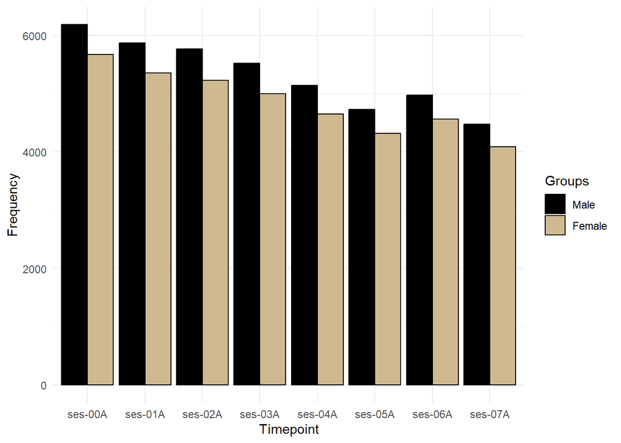

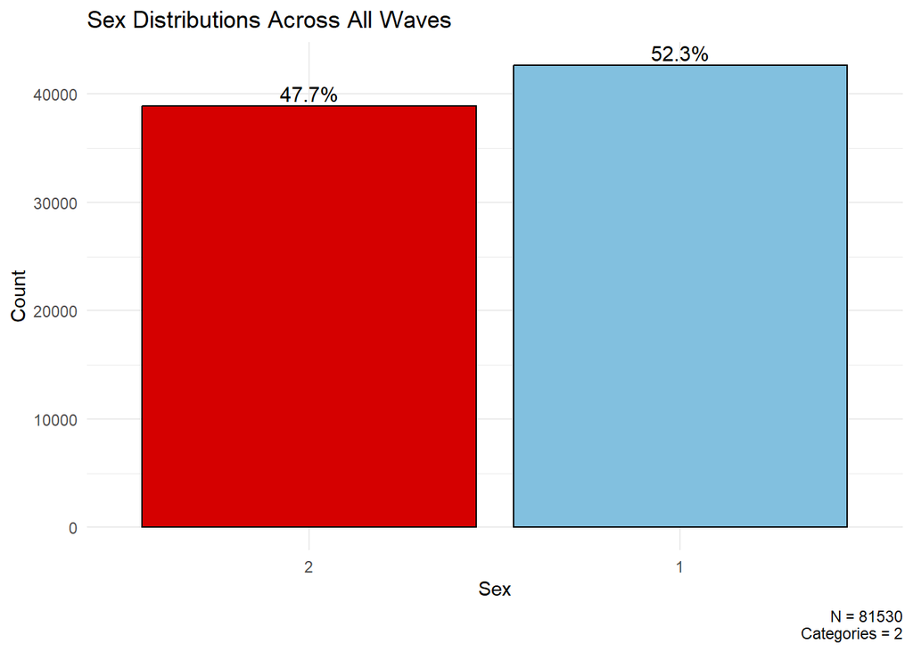

## Viz: Frequency of Participants Within Race-Ethnic Groups At Each Timepoint

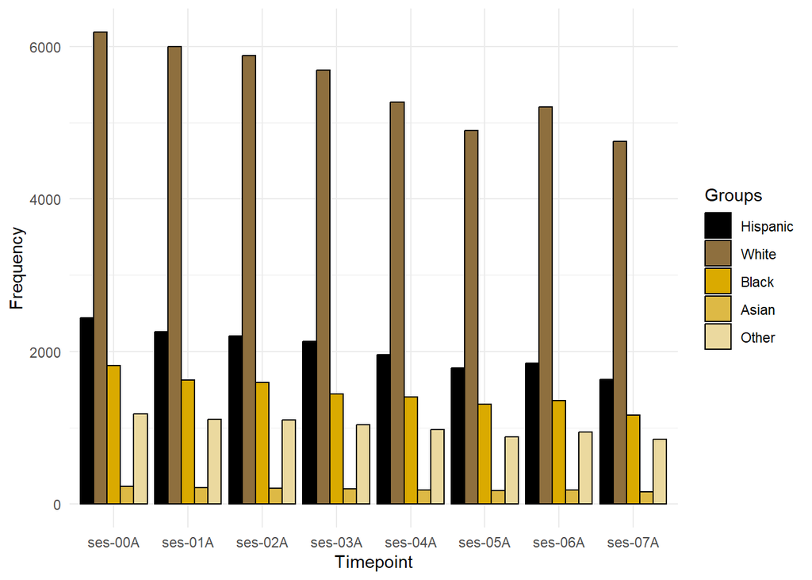

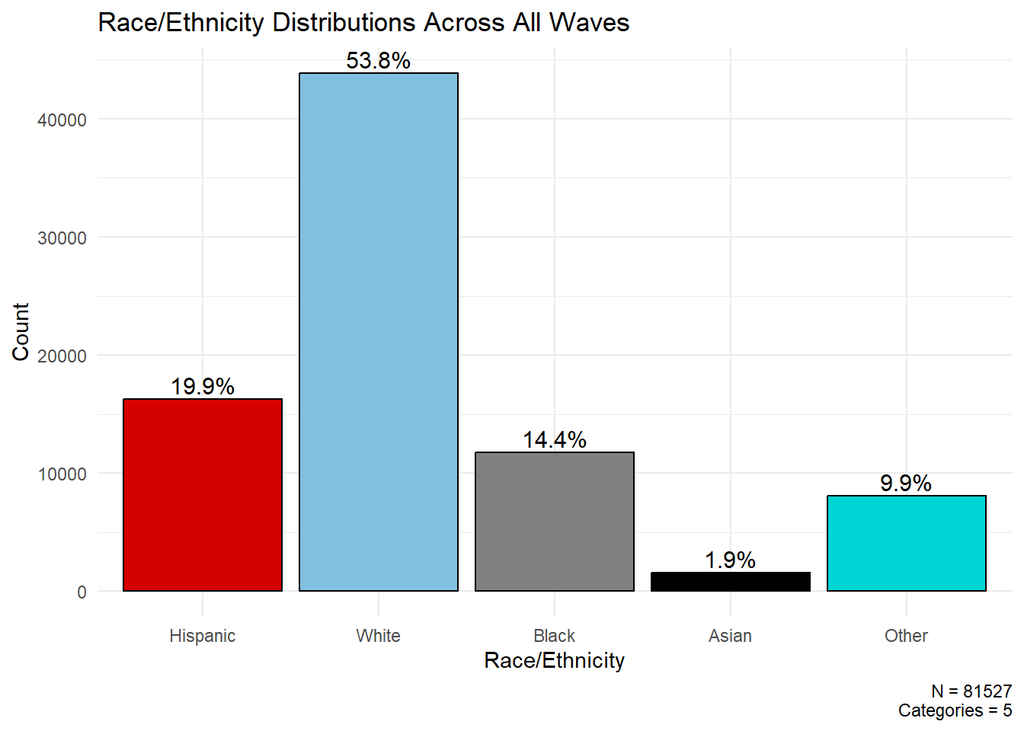

## Viz: Frequency of Reporting Parent’s Marital Status At Each Timepoint

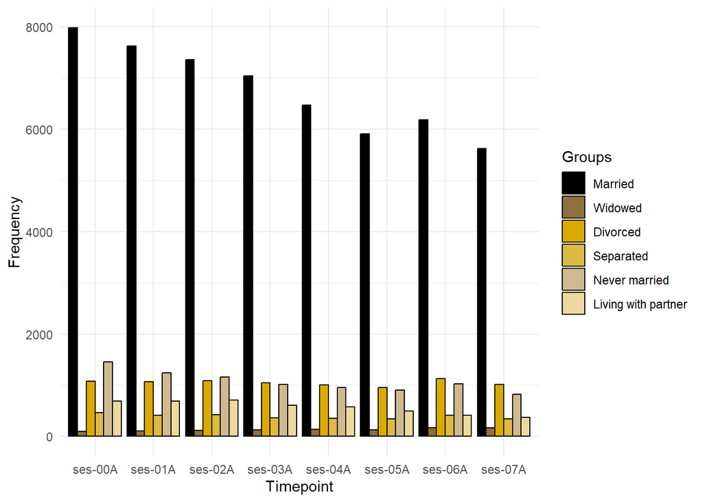

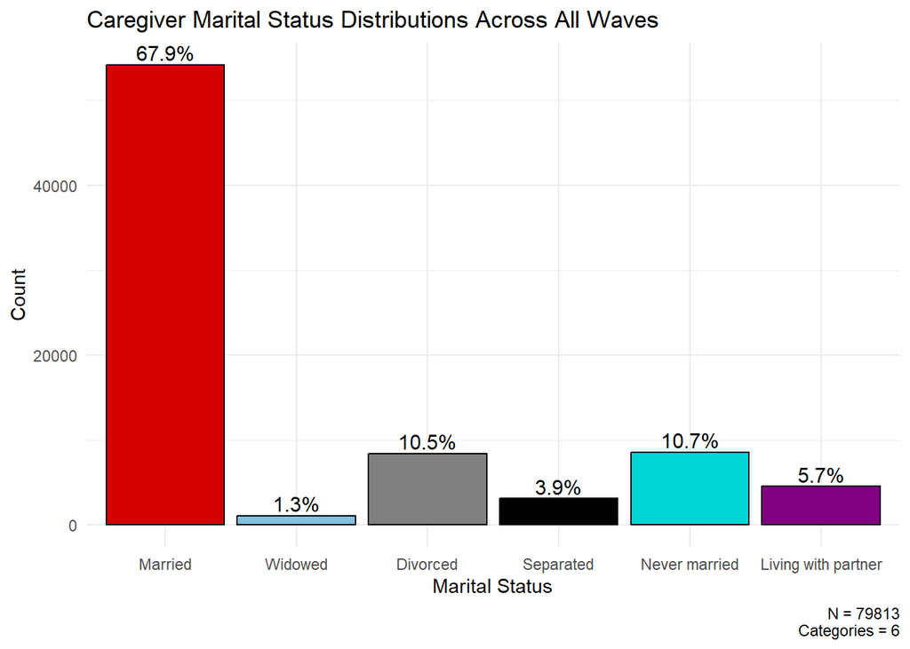

## Viz: Frequency of Participants Living Within a Multigenerational Home

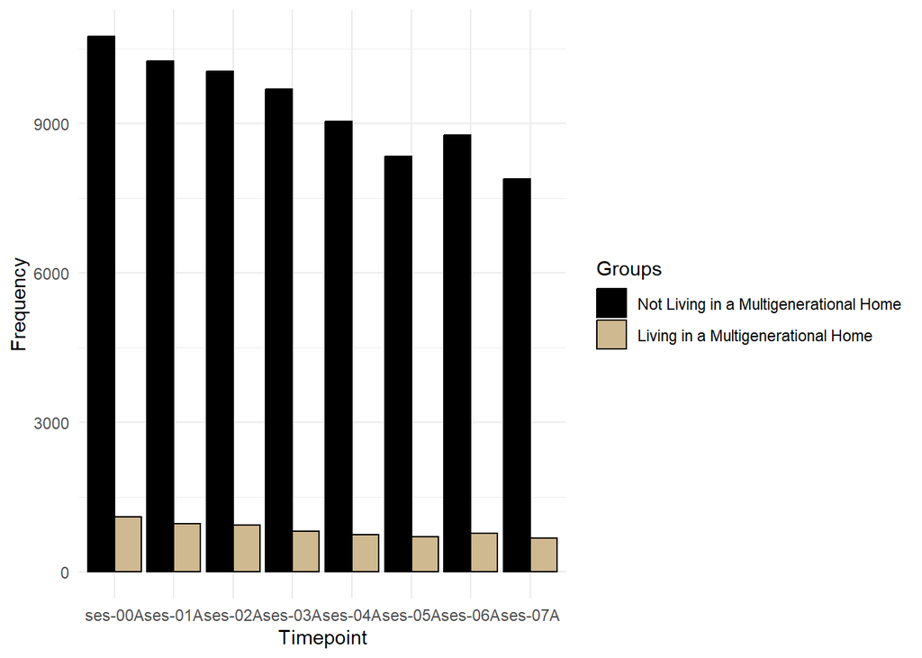

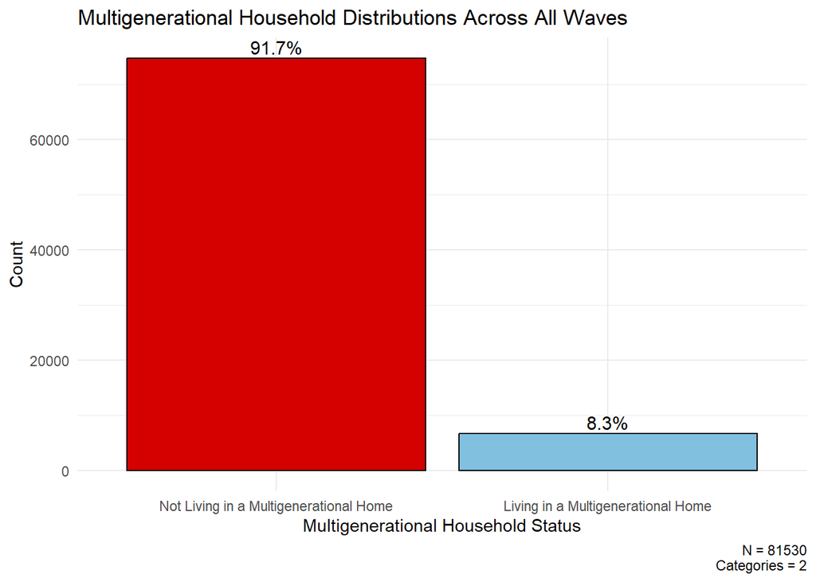

# Child Emotional/Behavioral Risk and Protective Factors

Child internalizing and externalizing behaviors were measured via checklist measures.

## Dataset(s) & Variables

**mh_y_bpm**: Youth-reported externalizing and internalizing symptoms

Externalizing: Taken from 7 questions on the Brief Problem Monitor (BPM) which were measured on a 3-point Likert scale with 0=not true, 2 = somewhat true, 2= very true, 777 = decline to answer, 999 = don’t know.

*mh_y_bpm__ext_001* (formerly bpm_2_y): I argue a lot

*mh_y_bpm__ext_002* (formerly bpm_6_y): I destroy things belonging to others

*mh_y_bpm__ext_003* (formerly bpm_7_y): I disobey my parents

*mh_y_bpm__ext_004* (formerly bpm_8_y): I disobey at school. Please select ” Not True ” if you are not in school at the time of this assessment.

*mh_y_bpm__ext_005* (formerly bpm_15_y): I am stubborn

*mh_y_bpm__ext_006* (formerly bpm_16_y): I have a hot temper

*mh_y_bpm__ext_007* (formerly bpm_17_y): I threaten to hurt people

*mh_y_bpm__ext_sum* (formerly bpm_y_scr_external_r): Sum [Validation: No more than 0 missing or declined]

*mh_y_bpm__ext_tscore* (formerly bpm_y_scr_external_t): T-score [Validation: No more than 0 missing or declined]

*mh_y_bpm__ext_nm* (formerly bpm_y_scr_external_nm): Number missing (externalizing)

Internalizing: Taken from 6 questions on the Brief Problem Monitor (BPM) which were measured on a 3-point Likert scale with 0 = not true, 1 = somewhat true, 2 = very true, 777 = decline to answer, 999 = don’t know.

*mh_y_bpm__int_001*: I feel worthless or inferior.

*mh_y_bpm__int_002*: I am too fearful or anxious.

*mh_y_bpm__int_003*: I feel too guilty.

*mh_y_bpm__int_004*: I am self-conscious or easily embarrassed.

*mh_y_bpm__int_005*: I am unhappy, sad, or depressed.

*mh_y_bpm__int_006*: I worry a lot.

*mh_y_bpm__int_sum*: Sum [Validation: No more than 0 missing or declined]

*mh_y_bpm__int_tscore*: T-score [Validation: No more than 0 missing or declined]

*mh_y_bpm__int_nm*: Number missing (internalizing)

**mh_p_cbcl**: Parent-reported externalizing and internalizing symptoms

Parent-reported externalizing symptoms were taken from the Child Behavior Checklist (CBCL), which includes rule-breaking and aggressive subscales. Parents indicted responses on a 3-point Likert scale with 0=not true and 2= very true. In order to match CBCL with BPM, we summed the rule-breaking and aggressive subscales of the CBCL to create an externalizing composite that excludes attention problems.

*mh_p_cbcl__synd__ext_sum*: Child Behavior Checklist [Parent] (Syndrome Scale - Externalizing): Sum of the rule-breaking behavior and aggressive behavior syndrome scales, excluding attention problems.

*mh_p_cbcl__synd__ext_nm*: Child Behavior Checklist [Parent] (Syndrome Scale - Externalizing): Number missing.

Parent-reported internalizing symptoms were taken from the Child Behavior Checklist (CBCL), which includes anxious/depressed, withdrawn/depressed, and somatic complaints syndrome scales. Parents indicated responses on a 3-point Likert scale with 0 = not true, 1 = somewhat or sometimes true, and 2 = very true.

*mh_p_cbcl__synd__int_sum*: Child Behavior Checklist [Parent] (Syndrome Scale - Internalizing): Sum of the anxious/depressed, withdrawn/depressed, and somatic complaints syndrome scales.

*mh_p_cbcl__synd__int_nm*: Child Behavior Checklist [Parent] (Syndrome Scale - Internalizing): Number missing.

Parent-reported attention problems were taken from the Child Behavior Checklist (CBCL) attention problems syndrome scale. Parents indicated responses on a 3-point Likert scale with 0 = not true, 1 = somewhat or sometimes true, and 2 = very true.

*mh_p_cbcl__synd__attn_sum*: Child Behavior Checklist [Parent] (Syndrome Scale - Attention problems): Sum [Validation: No more than 0 missing or declined]

*mh_p_cbcl__synd__attn_nm*: Child Behavior Checklist [Parent] (Syndrome Scale - Attention problems): Number missing

**mh_y_pai**:Youth-reported positive affect

Youth-reported positive affect was assessed using the NIH Toolbox Positive Affect Items [Youth]. Items capture the extent to which youth report positive emotional experiences. The sum score was retained as an indicator of youth positive affect.

*mh_y_pai_sum*: NIH Toolbox - Positive Affect Items [Youth]: Sum [Validation: None missing or declined]

*mh_y_pai_nm*: NIH Toolbox - Positive Affect Items [Youth]: Number missing

```r
mental_health_codebook <- tibble::tribble(
  ~construct, ~indicator, ~description, ~waves_measured,

  "Mental health", "<i>mh_y_bpm__ext_sum</i>",
  "Youth-reported Brief Problem Monitor (BPM) externalizing symptoms sum score. Based on 7 items assessing arguing, rule-breaking, aggression, stubbornness, temper, and threats toward others.",
  "Waves 1-6",

  "Mental health", "<i>mh_y_bpm__ext_tscore</i>",
  "Youth-reported Brief Problem Monitor (BPM) externalizing symptoms T-score.",
  "Waves 1-6",

  "Mental health", "<i>mh_y_bpm__int_sum</i>",
  "Youth-reported Brief Problem Monitor (BPM) internalizing symptoms sum score. Based on 6 items assessing anxiety, guilt, embarrassment, sadness/depression, worthlessness, and worry.",
  "Waves 1-6",

  "Mental health", "<i>mh_y_bpm__int_tscore</i>",
  "Youth-reported Brief Problem Monitor (BPM) internalizing symptoms T-score.",
  "Waves 1-6",

  "Mental health", "<i>mh_p_cbcl__synd__ext_sum</i>",
  "Parent-reported Child Behavior Checklist (CBCL) externalizing syndrome scale sum score. Composite of the rule-breaking behavior and aggressive behavior syndrome scales, excluding attention problems.",
  "All waves (0-7)",

  "Mental health", "<i>mh_p_cbcl__synd__int_sum</i>",
  "Parent-reported Child Behavior Checklist (CBCL) internalizing syndrome scale sum score. Composite of the anxious/depressed, withdrawn/depressed, and somatic complaints syndrome scales.",
  "All waves (0-7)",

  "Mental health", "<i>mh_p_cbcl__synd__attn_sum</i>",
  "Parent-reported Child Behavior Checklist (CBCL) attention problems syndrome scale sum score.",
  "All waves (0-7)",

  "Positive affect", "<i>mh_y_pai_sum</i>",
  "Youth-reported NIH Toolbox Positive Affect Items sum score. Higher values indicate greater positive emotional experiences and positive affect.",
  "Waves 1, 3, and 5"
)

mental_health_codebook %>%
  dplyr::arrange(
    factor(
      construct,
      levels = c("Mental health", "Positive affect")
    ),
    indicator
  ) %>%
  kableExtra::kbl(
    format = "html",
    col.names = c("Construct", "Variable Name", "Variable Description", "Waves Measured"),
    escape = FALSE
  ) %>%
  kableExtra::kable_styling(
    bootstrap_options = c("hover", "condensed"),
    full_width = TRUE
  ) %>%
  kableExtra::collapse_rows(
    columns = 1,
    valign = "top"
  )
```

| Construct | Variable Name | Variable Description | Waves Measured |
| --- | --- | --- | --- |
| Mental health | *mh_p_cbcl__synd__attn_sum* | Parent-reported Child Behavior Checklist (CBCL) attention problems syndrome scale sum score. | All waves (0-7) |
|  | *mh_p_cbcl__synd__ext_sum* | Parent-reported Child Behavior Checklist (CBCL) externalizing syndrome scale sum score. Composite of the rule-breaking behavior and aggressive behavior syndrome scales, excluding attention problems. | All waves (0-7) |
|  | *mh_p_cbcl__synd__int_sum* | Parent-reported Child Behavior Checklist (CBCL) internalizing syndrome scale sum score. Composite of the anxious/depressed, withdrawn/depressed, and somatic complaints syndrome scales. | All waves (0-7) |
|  | *mh_y_bpm__ext_sum* | Youth-reported Brief Problem Monitor (BPM) externalizing symptoms sum score. Based on 7 items assessing arguing, rule-breaking, aggression, stubbornness, temper, and threats toward others. | Waves 1-6 |
|  | *mh_y_bpm__ext_tscore* | Youth-reported Brief Problem Monitor (BPM) externalizing symptoms T-score. | Waves 1-6 |
|  | *mh_y_bpm__int_sum* | Youth-reported Brief Problem Monitor (BPM) internalizing symptoms sum score. Based on 6 items assessing anxiety, guilt, embarrassment, sadness/depression, worthlessness, and worry. | Waves 1-6 |
|  | *mh_y_bpm__int_tscore* | Youth-reported Brief Problem Monitor (BPM) internalizing symptoms T-score. | Waves 1-6 |
| Positive affect | *mh_y_pai_sum* | Youth-reported NIH Toolbox Positive Affect Items sum score. Higher values indicate greater positive emotional experiences and positive affect. | Waves 1, 3, and 5 |

## Data Cleaning & Variable Creation

```r
#Subset brief problem monitor dataset to variables of interest
s.bpm <- c("participant_id", "session_id", "mh_y_bpm__ext_sum", "mh_y_bpm__int_sum")
bpm_subset <- bpm[s.bpm]

#Subset CBCL dataset to variables of interest
s.cbcl <- c("participant_id", "session_id", "mh_p_cbcl__synd__ext_sum", "mh_p_cbcl__synd__int_sum", "mh_p_cbcl__synd__attn_sum")
cbcl_subset <- cbcl[s.cbcl]

# Subset PAI dataset to variables of interest
s.pai <- c("participant_id", "session_id","mh_y_pai_sum")
pai_subset <- pai[s.pai]

#merge
mh_checklists <- merge(cbcl_subset, bpm_subset, by=c("participant_id", "session_id"), all = TRUE)
mh_checklists <- merge(mh_checklists,pai_subset,by = c("participant_id", "session_id"),all = TRUE)

#Drop assessments that are not annual assessments (indicated by M at the end of the session_id)
mh <- mh_checklists %>%
  filter(session_id == "ses-00A" | session_id == "ses-01A" | session_id == "ses-02A" | session_id == "ses-03A" | session_id == "ses-04A" | session_id == "ses-05A" | session_id == "ses-06A")

mh = mh %>%
  mutate(timepoint = str_extract(session_id, "\\d+") %>% as.integer())
```

## Descriptive Statistics

Child and Parent Reported Internalizing and Externalizing Summary Statistics

|  | vars | n | mean | sd | median | trimmed | mad | min | max | range | skew | kurtosis | se |
| --- | --- | --- | --- | --- | --- | --- | --- | --- | --- | --- | --- | --- | --- |
| participant_id* | 1 | 11858 | 5929.500000 | 3423.254080 | 5929.5 | 5929.500000 | 4395.1677 | 1 | 11858 | 11857 | 0.0000000 | -1.2003036 | 31.4364438 |
| mh_y_bpm__ext_sum_0 | 2 | 0 | NaN | NA | NA | NaN | NA | Inf | -Inf | -Inf | NA | NA | NA |
| mh_y_bpm__ext_sum_1 | 3 | 10442 | 1.987742 | 2.011804 | 2.0 | 1.689730 | 1.4826 | 0 | 13 | 13 | 1.2759961 | 1.7986875 | 0.0196876 |
| mh_y_bpm__ext_sum_2 | 4 | 10403 | 2.083341 | 2.007646 | 2.0 | 1.814129 | 1.4826 | 0 | 13 | 13 | 1.1518865 | 1.4414556 | 0.0196837 |
| mh_y_bpm__ext_sum_3 | 5 | 10038 | 2.085077 | 1.987992 | 2.0 | 1.823207 | 1.4826 | 0 | 13 | 13 | 1.1216148 | 1.3326874 | 0.0198423 |
| mh_y_bpm__ext_sum_4 | 6 | 9406 | 2.171167 | 2.019638 | 2.0 | 1.920276 | 1.4826 | 0 | 14 | 14 | 1.0699115 | 1.2794358 | 0.0208243 |
| mh_y_bpm__ext_sum_5 | 7 | 8642 | 2.260241 | 2.042419 | 2.0 | 2.016778 | 1.4826 | 0 | 12 | 12 | 0.9725926 | 0.7988768 | 0.0219704 |
| mh_y_bpm__ext_sum_6 | 8 | 1205 | 2.145228 | 2.075323 | 2.0 | 1.866321 | 1.4826 | 0 | 13 | 13 | 1.2389193 | 1.9645288 | 0.0597850 |
| mh_y_bpm__int_sum_0 | 9 | 0 | NaN | NA | NA | NaN | NA | Inf | -Inf | -Inf | NA | NA | NA |
| mh_y_bpm__int_sum_1 | 10 | 10562 | 1.742378 | 2.113976 | 1.0 | 1.353965 | 1.4826 | 0 | 12 | 12 | 1.5976410 | 2.7006925 | 0.0205697 |
| mh_y_bpm__int_sum_2 | 11 | 10507 | 1.815076 | 2.228087 | 1.0 | 1.395623 | 1.4826 | 0 | 12 | 12 | 1.6504949 | 2.8054998 | 0.0217367 |
| mh_y_bpm__int_sum_3 | 12 | 10098 | 2.031887 | 2.386364 | 1.0 | 1.602351 | 1.4826 | 0 | 12 | 12 | 1.4834566 | 2.0650877 | 0.0237476 |
| mh_y_bpm__int_sum_4 | 13 | 9448 | 2.399661 | 2.658720 | 2.0 | 1.951984 | 2.9652 | 0 | 12 | 12 | 1.3162159 | 1.3231334 | 0.0273529 |
| mh_y_bpm__int_sum_5 | 14 | 8708 | 2.760680 | 2.832308 | 2.0 | 2.336826 | 2.9652 | 0 | 12 | 12 | 1.1102710 | 0.6356611 | 0.0303516 |
| mh_y_bpm__int_sum_6 | 15 | 1215 | 2.893004 | 2.862599 | 2.0 | 2.494347 | 2.9652 | 0 | 12 | 12 | 0.9982404 | 0.3171531 | 0.0821244 |
| mh_p_cbcl__synd__ext_sum_0 | 16 | 11853 | 4.452797 | 5.865137 | 2.0 | 3.263419 | 2.9652 | 0 | 49 | 49 | 2.2992655 | 7.0239584 | 0.0538721 |
| mh_p_cbcl__synd__ext_sum_1 | 17 | 11201 | 4.178466 | 5.661936 | 2.0 | 3.007365 | 2.9652 | 0 | 47 | 47 | 2.4034590 | 7.6114169 | 0.0534979 |
| mh_p_cbcl__synd__ext_sum_2 | 18 | 10906 | 3.926371 | 5.592947 | 2.0 | 2.741118 | 2.9652 | 0 | 50 | 50 | 2.5476006 | 8.6699784 | 0.0535560 |
| mh_p_cbcl__synd__ext_sum_3 | 19 | 10230 | 3.911437 | 5.554164 | 2.0 | 2.736559 | 2.9652 | 0 | 49 | 49 | 2.5554438 | 8.8583924 | 0.0549137 |
| mh_p_cbcl__synd__ext_sum_4 | 20 | 9525 | 3.627717 | 5.490092 | 1.0 | 2.417268 | 1.4826 | 0 | 50 | 50 | 2.7039889 | 9.7280956 | 0.0562532 |
| mh_p_cbcl__synd__ext_sum_5 | 21 | 8786 | 3.784999 | 5.768823 | 2.0 | 2.521479 | 2.9652 | 0 | 55 | 55 | 2.9032682 | 11.6856973 | 0.0615448 |
| mh_p_cbcl__synd__ext_sum_6 | 22 | 9354 | 3.250374 | 5.327383 | 1.0 | 2.047835 | 1.4826 | 0 | 52 | 52 | 3.0954627 | 13.0225113 | 0.0550827 |
| mh_p_cbcl__synd__int_sum_0 | 23 | 11853 | 5.047498 | 5.528912 | 3.0 | 4.073184 | 4.4478 | 0 | 51 | 51 | 1.9363445 | 5.1174594 | 0.0507838 |
| mh_p_cbcl__synd__int_sum_1 | 24 | 11201 | 5.114990 | 5.561426 | 3.0 | 4.147082 | 4.4478 | 0 | 48 | 48 | 1.9189707 | 5.0154959 | 0.0525482 |
| mh_p_cbcl__synd__int_sum_2 | 25 | 10906 | 4.938566 | 5.666773 | 3.0 | 3.898464 | 4.4478 | 0 | 50 | 50 | 2.0625215 | 5.7379294 | 0.0542629 |
| mh_p_cbcl__synd__int_sum_3 | 26 | 10230 | 5.139589 | 5.936318 | 3.0 | 4.042766 | 4.4478 | 0 | 49 | 49 | 2.0144928 | 5.3483790 | 0.0586921 |
| mh_p_cbcl__synd__int_sum_4 | 27 | 9525 | 5.215118 | 6.239264 | 3.0 | 4.026506 | 4.4478 | 0 | 51 | 51 | 2.0469603 | 5.4734773 | 0.0639294 |
| mh_p_cbcl__synd__int_sum_5 | 28 | 8786 | 5.661848 | 6.581760 | 4.0 | 4.424324 | 4.4478 | 0 | 51 | 51 | 2.0046202 | 5.0856707 | 0.0702177 |
| mh_p_cbcl__synd__int_sum_6 | 29 | 9352 | 5.016895 | 6.239107 | 3.0 | 3.787891 | 4.4478 | 0 | 51 | 51 | 2.1054928 | 5.6172880 | 0.0645164 |
| mh_p_cbcl__synd__attn_sum_0 | 30 | 11853 | 2.977643 | 3.494041 | 2.0 | 2.358220 | 2.9652 | 0 | 20 | 20 | 1.4369125 | 1.8318485 | 0.0320933 |
| mh_p_cbcl__synd__attn_sum_1 | 31 | 11201 | 2.859834 | 3.431731 | 2.0 | 2.235688 | 2.9652 | 0 | 19 | 19 | 1.4792310 | 1.9331331 | 0.0324254 |
| mh_p_cbcl__synd__attn_sum_2 | 32 | 10906 | 2.732991 | 3.331625 | 1.0 | 2.115631 | 1.4826 | 0 | 19 | 19 | 1.5203179 | 2.1388106 | 0.0319024 |
| mh_p_cbcl__synd__attn_sum_3 | 33 | 10231 | 2.782230 | 3.339166 | 2.0 | 2.175443 | 2.9652 | 0 | 20 | 20 | 1.4702386 | 1.9444809 | 0.0330125 |
| mh_p_cbcl__synd__attn_sum_4 | 34 | 9525 | 2.567874 | 3.289468 | 1.0 | 1.929799 | 1.4826 | 0 | 20 | 20 | 1.5984564 | 2.3368727 | 0.0337049 |
| mh_p_cbcl__synd__attn_sum_5 | 35 | 8786 | 2.586501 | 3.268880 | 1.0 | 1.964438 | 1.4826 | 0 | 18 | 18 | 1.5656074 | 2.2547158 | 0.0348741 |
| mh_p_cbcl__synd__attn_sum_6 | 36 | 9349 | 2.285378 | 3.122253 | 1.0 | 1.653656 | 1.4826 | 0 | 19 | 19 | 1.7390064 | 3.0088928 | 0.0322913 |
| mh_y_pai_sum_0 | 37 | 0 | NaN | NA | NA | NaN | NA | Inf | -Inf | -Inf | NA | NA | NA |
| mh_y_pai_sum_1 | 38 | 10138 | 21.483231 | 3.988709 | 22.0 | 21.748274 | 4.4478 | 9 | 27 | 18 | -0.5266599 | -0.2993597 | 0.0396147 |
| mh_y_pai_sum_2 | 39 | 0 | NaN | NA | NA | NaN | NA | Inf | -Inf | -Inf | NA | NA | NA |
| mh_y_pai_sum_3 | 40 | 9753 | 20.167231 | 4.076185 | 20.0 | 20.268230 | 4.4478 | 9 | 27 | 18 | -0.2061050 | -0.4369308 | 0.0412748 |
| mh_y_pai_sum_4 | 41 | 0 | NaN | NA | NA | NaN | NA | Inf | -Inf | -Inf | NA | NA | NA |
| mh_y_pai_sum_5 | 42 | 8408 | 20.186965 | 4.175439 | 20.0 | 20.283740 | 4.4478 | 9 | 27 | 18 | -0.1720191 | -0.5524780 | 0.0455361 |
| mh_y_pai_sum_6 | 43 | 0 | NaN | NA | NA | NaN | NA | Inf | -Inf | -Inf | NA | NA | NA |

## Viz: Distributions across all waves

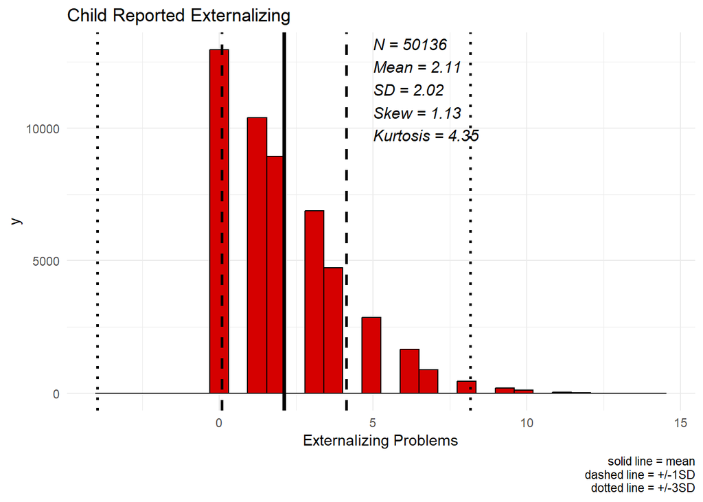

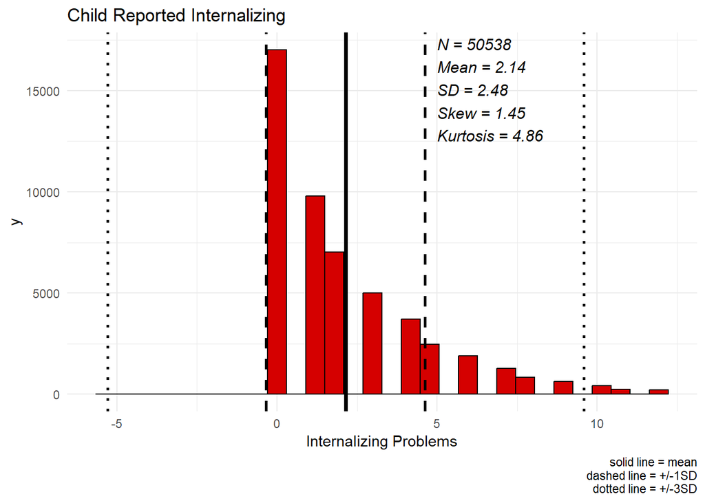

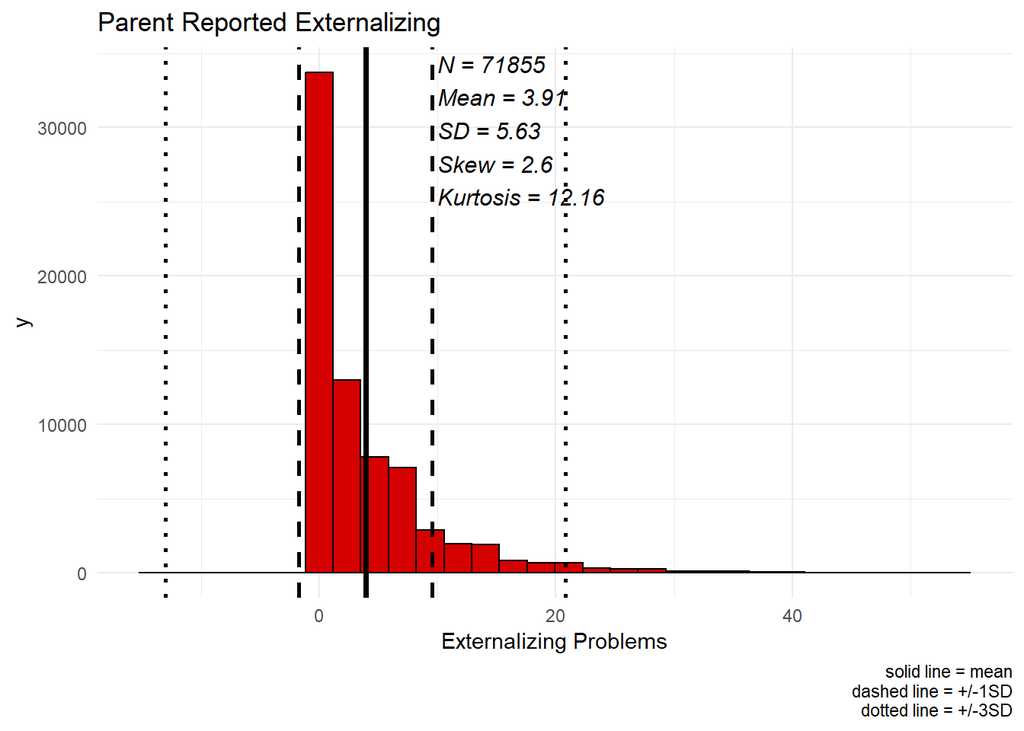

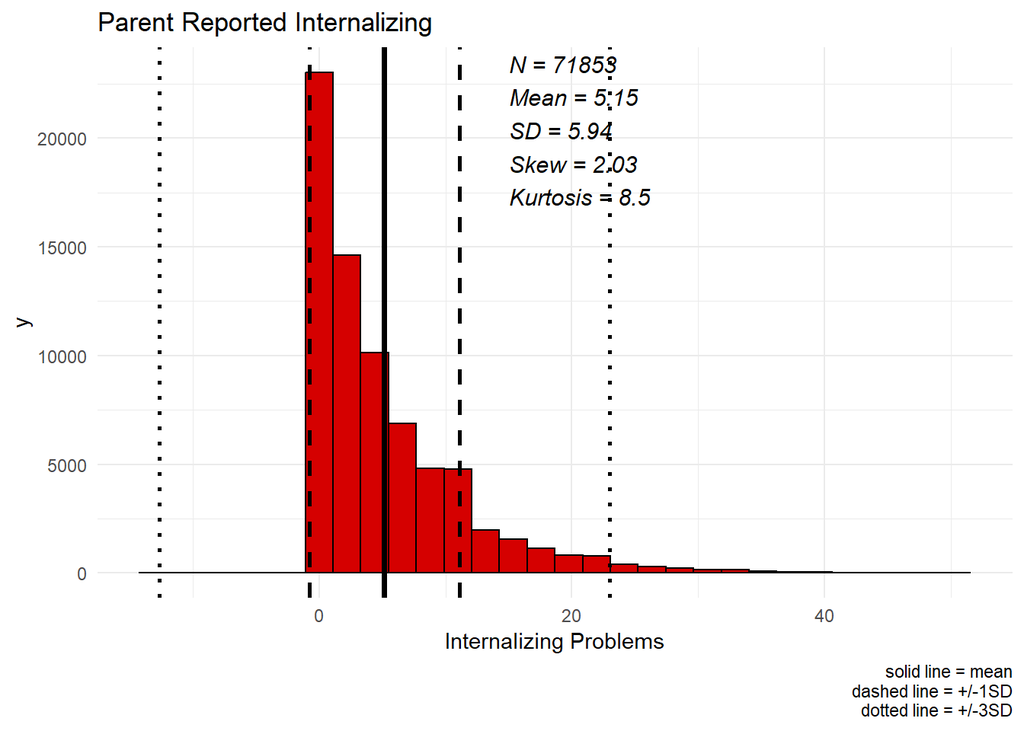

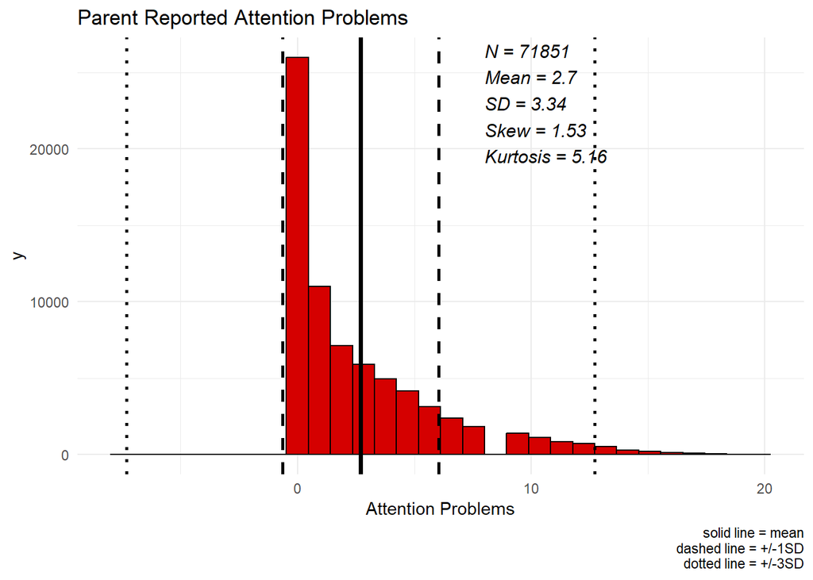

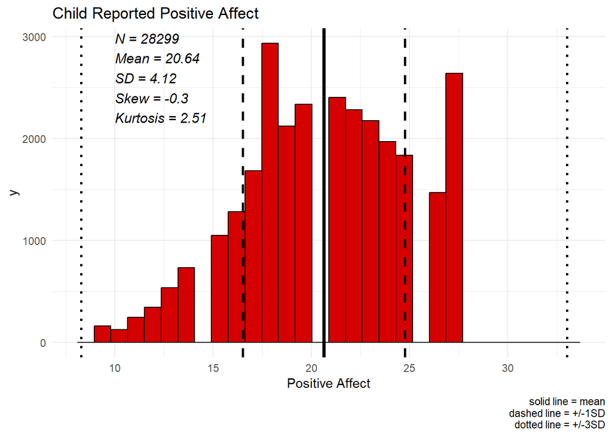

## Viz: Distributions by wave

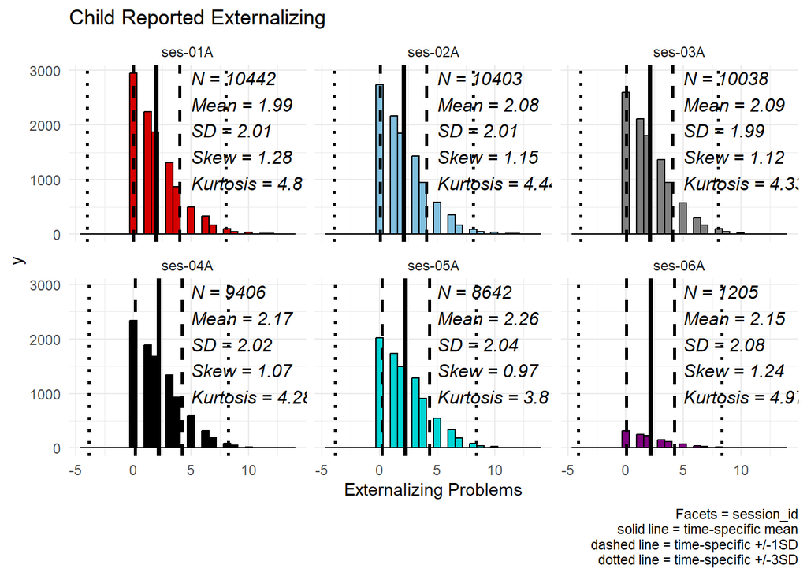

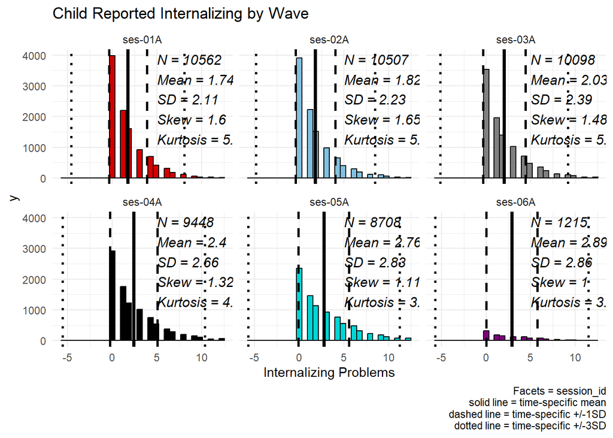

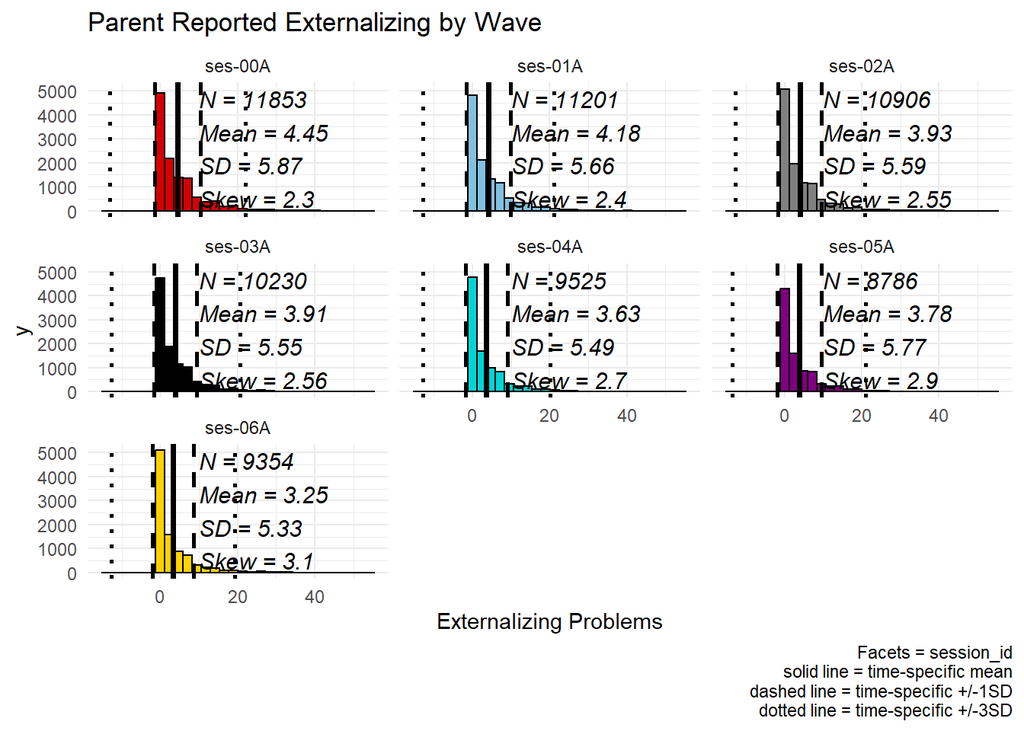

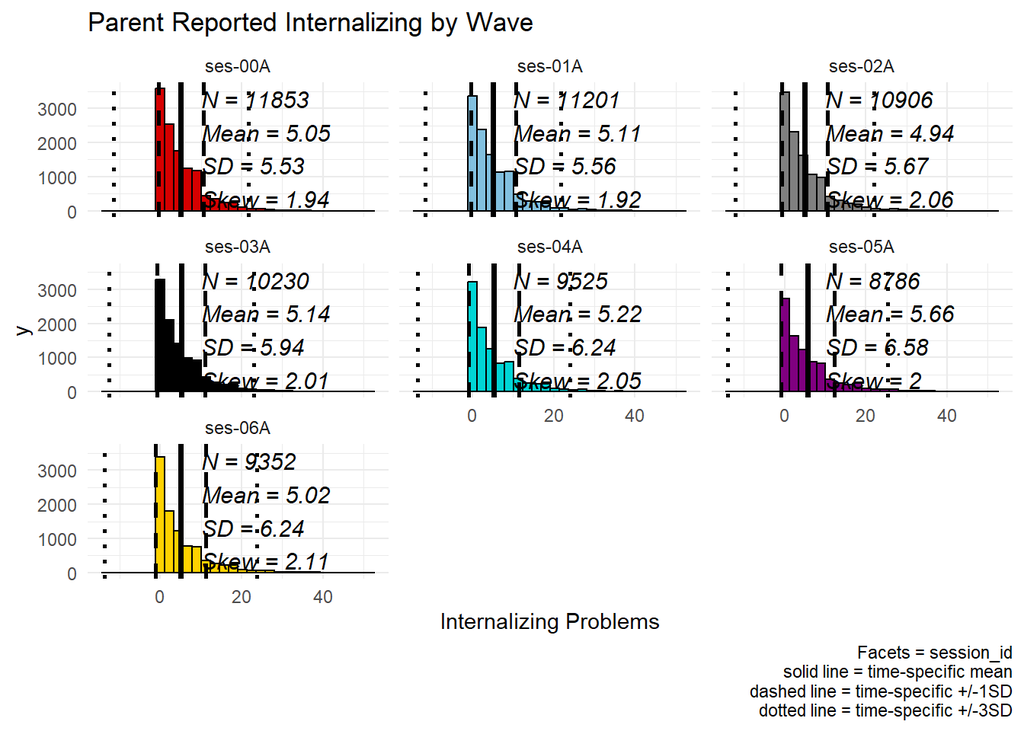

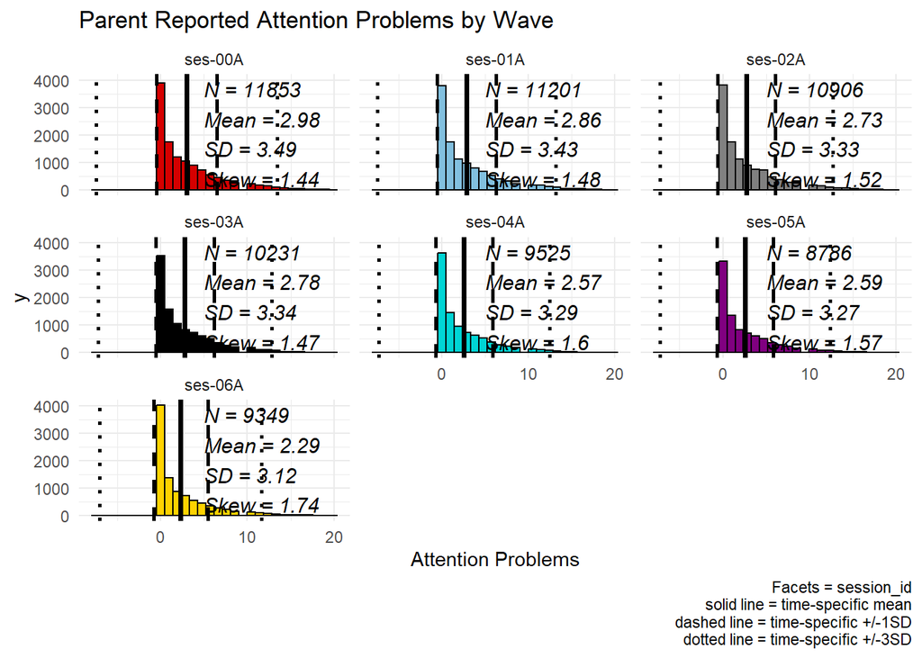

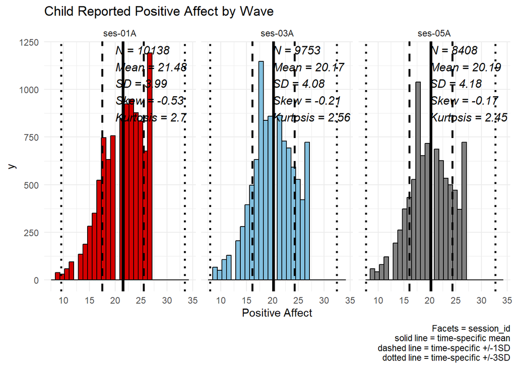

## Viz: Longitudinal Plots

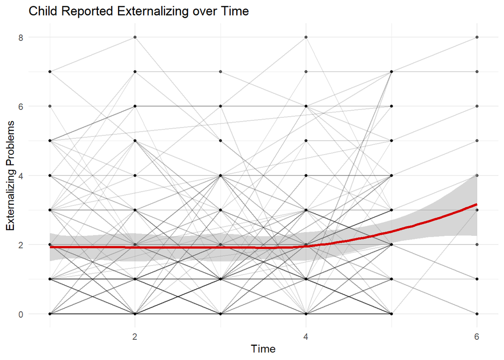

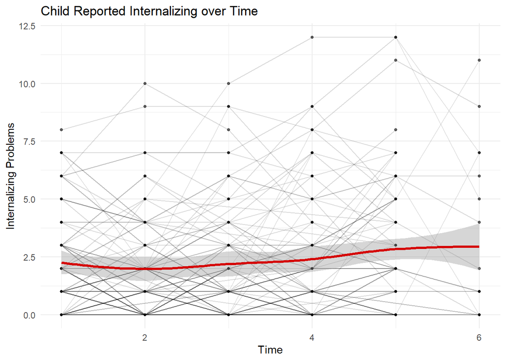

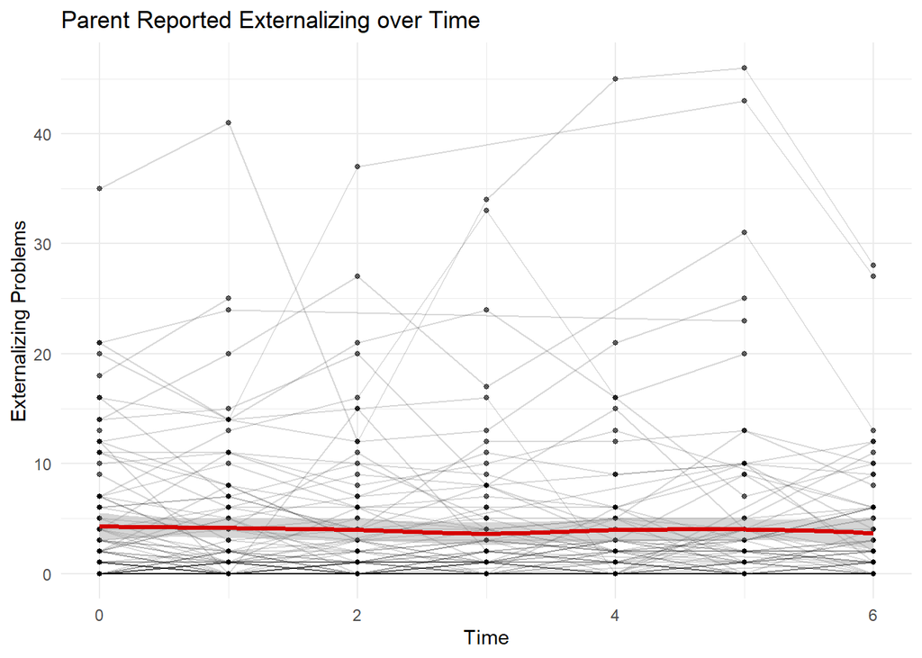

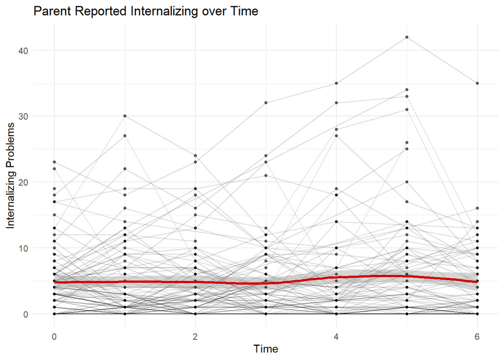

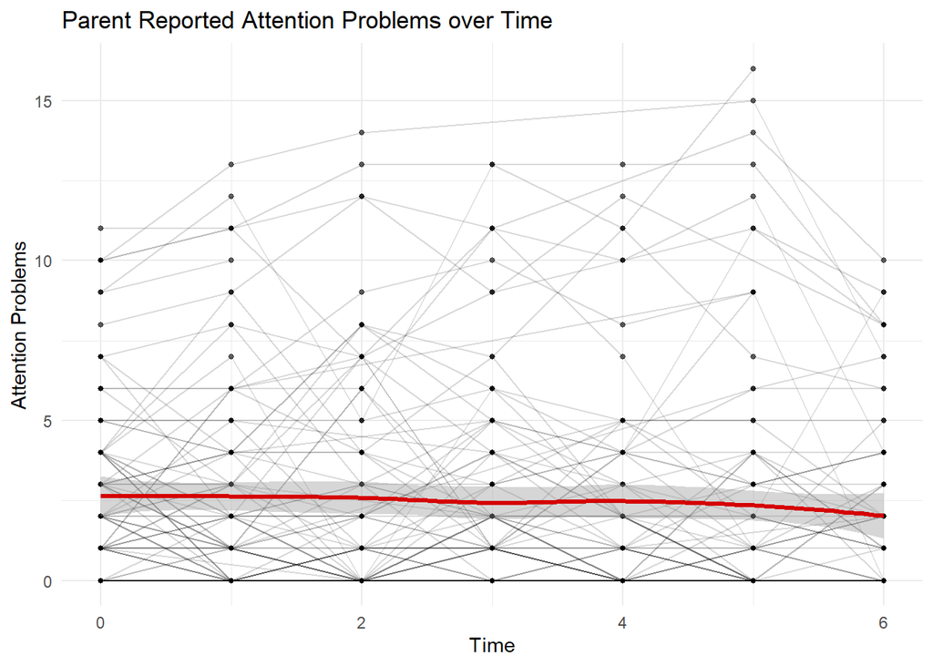

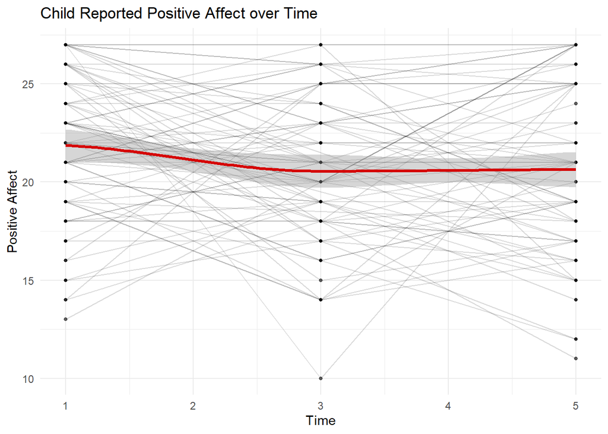

# Substance Use

We constructed uptake continuum measures for 1) alcohol, 2) tobacco, and 3) marijuana.

Continuum scoring depended upon items available at each assessment (e.g., follow-ups ask about the last 12 months, baseline is lifetime). Categories were collapsed or expanded depending on rates of endorsement but generally follow patterns of milestone attainment.

## Datasets & Variables

Alcohol

**Su_y_sui**

*su_y_sui__hrd__alc_001* (formerly tlfb_alc & tlfb_alc_l):Have you heard of—-alcohol, such as beer, wine, or liquor? 0 = No; 1 = Yes (NOTE: full data only available for ses-00A, 409 responses available for ses-01A, 140 responses available for ses-02A) *su_y_sui__use__alc_001* & *su_y_sui__use__alc_001__l* (formerly tlfb_alc_use & tlfb_alc_use_l): Have you ever used: A full drink of beer, wine or liquor (rum, vodka, gin, whiskey) 0 = No; 1 = Yes

**su_y_lowuse**

*su_y_lowuse__isip_002* & *su_y_lowuse__isip_002__l*: A sip of alcohol such as beer, wine or liquor (rum, vodka, gin, whiskey).0 = No; 1 = Yes

**su_y_itu**

*su_y_itu__alc_001* (formerly path_alc_youth2 & path_alc_youth2_l): Have you ever been curious about drinking alcohol? 1=Very curious; 2 Somewhat curious; 3 = A little curious; 4 = Not at all curious; 999= Don’t know; 777 = Refused to answer *su_y_itu__alc_002* (formerly path_alc_youth5 & path_alc_youth5_l): Do you think you will try alcohol soon? 1 = Definitely yes; 2 = Probably yes; 3 = Probably not; 4= Definitely not; 999= Don’t know; 777 = Refused to answer *su_y_itu__alc_003* (formerly path_alc_youth8 & path_alc_youth8_l): If one of your best friends were to offer you alcohol, would you try it? 1 = definitely yes; 2 = probably yes; 3 = Probably Not; 4 = definitely not; 999= Don’t know; 777 = Refused to answer

**su_y_tlfb**

*su_y_tlfb__alc__binge_ud* (formerly tlfb_cal_scr_num_bde): Alcohol - Binge episodes: Number of use days *su_y_tlfb__alc_ud* (formerly tlfb_cal_scr_alc_ud): Alcohol: Number of use days *su_y_tlfb__alc_mean* (formerly tlfb_cal_scr_alc_avg): Alcohol: Average dose

**su_y_alcsre**

*su_y_alcsre__6mo_count* (formerly subj_resp_alc_total_6mo & subj_resp_alc_total_6mo_i): Number of subjective experiences from drinking alcohol during in the past 6 months *su_y_alcsre__hvy_count* (formerly subj_resp_alc_total_heavy & subj_resp_alc_total_heavy_i): Number of subjective experiences from drinking alcohol during their heaviest drinking period.

Tobacco

**Su_y_sui**

*su_y_sui__hrd__nic_001* (formerly tlfb_tob & tlfb_tob_l): Have you heard of tobacco products, such as cigarettes, smokeless tobacco, cigars, hookah, electronic or e-cigarettes, or Juul? 0 = No; 1 = Yes (NOTE: full data only available for ses-00A, 712 reponses for ses-01A, 266 responses for ses-02A) *su_y_sui__use__nic__cig_001* & *su_y_sui__use__nic__cig_001__l* (formerly tlfb_cig_use & tlfb_cig_use_l): Tobacco cigarette - more than just a puff.0 = No; 1 = Yes

**su_y_lowuse**

*su_y_lowuse__nic_001* & *su_y_lowuse__nic_001__l* (formerly first_nicotine_1 & first_nicotine_1_l): Have you had a puff of a cigarette, electronic nicotine or vaping products, such as e-cigarettes, vape pens, JUULs, hookah, cigar or pipe. 0 = No; 1 = Yes

**su_y_itu**

*su_y_itu__nic_001* (formerly path_alc_youth1 & path_alc_youth1_l): Have you ever been curious about using a tobacco product such as cigarettes, e-cigarettes, hookah, or cigars? 1 = Very curious; 2 = Somewhat curious; 3 = A little curious; 4 = Not at all curious; 999= Don’t know; 777 = Refused to answer *su_y_itu__nic_002* (formerly path_alc_youth4 & path_alc_youth4_l): Do you think you will try a tobacco product soon? 1 = Definitely yes; 2 = Probably yes; 3 = Probably not; 4 = Definitely not; 999= Don’t know; 777 = Refused to answer *su_y_itu__nic_003* (formerly path_alc_youth7 & path_alc_youth7_l): If one of your best friends were to offer you a tobacco product, would you try it? 1 = Definitely yes; 2 = Probably yes; 3 = Probably not; 4 = Definitely not; 999= Don’t know; 777 = Refused to answer

**su_y_tlfb**

*su_y_tlfb__nic__cig_mean* (formerly tlfb_cal_scr_cig_avg): Nicotine - Cigarettes: Average dose *su_y_tlfb__nic__cig_ud* (formerly tlfb_cal_scr_cig_ud): Nicotine - Cigarettes: Number of use days

**su_y_nicsre**

*su_y_nicsre__cig_sum* (formerly res_tobacco_total_cig & res_tobacco_total_cig_i): Total intensity of positive and negative effects of first cigarette use.

Marijuana

**Su_y_sui**

*su_y_sui__hrd__mj_001* (formerly tlfb_mj & tlfb_mj_l): Have you ever heard of marijuana, weed, pot, blunts, dabs, marijuana drinks or food with marijuana? 0 = No; 1 = Yes (NOTE: full data only available for ses-00A, 4888 response available for ses-01A, 2375 responses available for ses-02A) *su_y_sui__use__mj__puff_001* & *su_y_sui__use__mj__puff_001__l* (formerly tlfb_mj_puff & tlfb_mj_puff_l): Have you ever used: A puff or eaten any marijuana, also called pot, grass, weed or ganja? 0 = No; 1 = Yes *su_y_sui__use__mj__smoke_001* & *su_y_sui__use__mj__smoke_001__l* (formerly tlfb_mj_use & tlfb_mj_use_l): Have you ever used: Smoked marijuana, also called pot, grass, weed, ganja - more than just a puff? 0 = No; 1 = Yes

**su_y_tlfb**

*su_y_tlfb__mj__smoke_mean* (formerly tlfb_cal_scr_smj_avg): Average smoked MJ on use days *su_y_tlfb__mj__smoke_ud* (formerly tlfb_cal_scr_smj_ud): Marijuana - Smoked: Number of use days

**su_y_itu**

*su_y_itu__mj_001* (formerly path_alc_youth3 & path_alc_youth3_l): Have you ever been curious about trying marijuana? 1 = Very curious; 2 = Somewhat curious; 3 = A little curious; 4 = Not at all curious; 999= Don’t know; 777 = Refused to answer *su_y_itu__mj_002* (formerly path_alc_youth6 & path_alc_youth6_l): Do you think you will try marijuana soon? 1 = Definitely yes; 2 = Probably yes; 3 = Probably not; 4 = Definitely not; 999= Don’t know; 777 = Refused to answer *su_y_itu__mj_003* (formerly path_alc_youth9 & path_alc_youth9_l): If one of your best friends were to offer you marijuana, would you try it? 1 = Definitely yes; 2 = Probably yes; 3 = Probably not; 4 = Definitely not; 999= Don’t know; 777 = Refused to answer

**su_y_mjsre**

*su_y_mjsre_sum* (formerly sub_res_mj_total & sub_res_mj_total_i): total number and severity of subjective responses for first marijuana use episode.

## Data Cleaning

```r
#Subset sui dataset to variables of interest
s.sui <- c("participant_id", "session_id", "su_y_sui__hrd__alc_001", "su_y_sui__use__alc_001", "su_y_sui__use__alc_001__l", "su_y_sui__hrd__nic_001", "su_y_sui__use__nic__cig_001", "su_y_sui__use__nic__cig_001__l", "su_y_sui__hrd__mj_001", "su_y_sui__use__mj__puff_001", "su_y_sui__use__mj__puff_001__l", "su_y_sui__use__mj__smoke_001", "su_y_sui__use__mj__smoke_001__l")
sui_subset <- sui[s.sui]

#Subset lowuse dataset to variables of interest
s.lowuse <- c("participant_id", "session_id", "su_y_lowuse__isip_002", "su_y_lowuse__isip_002__l", "su_y_lowuse__nic_001", "su_y_lowuse__nic_001__l")
lowuse_subset <- lowuse[s.lowuse]

#Subset intention to use (itu) dataset to variables of interest
s.itu <- c("participant_id", "session_id", "su_y_itu__alc_001", "su_y_itu__alc_002", "su_y_itu__alc_003", "su_y_itu__nic_001", "su_y_itu__nic_002", "su_y_itu__nic_003", "su_y_itu__mj_001", "su_y_itu__mj_002", "su_y_itu__mj_003")
itu_subset <- itu[s.itu]

#Subset tlfb dataset to variables of interest
s.tlfb <- c("participant_id", "session_id", "su_y_tlfb__alc__binge_ud", "su_y_tlfb__alc_ud", "su_y_tlfb__alc_mean", "su_y_tlfb__nic__cig_mean", "su_y_tlfb__nic__cig_ud", "su_y_tlfb__mj__smoke_mean", "su_y_tlfb__mj__smoke_ud")
tlfb_subset <- tlfb[s.tlfb]

#Subset subjective experiences dataset to variables of interest
#alcohol
s.alcsre <- c("participant_id", "session_id", "su_y_alcsre__6mo_count", "su_y_alcsre__hvy_count")
alcsre_subset <- alcsre[s.alcsre]

#Tobacco
s.nicsre <- c("participant_id", "session_id", "su_y_nicsre__cig_sum")
nicsre_subset <- nicsre[s.nicsre]

#Marijuana
s.mjsre <- c("participant_id", "session_id", "su_y_mjsre_sum")
mjsre_subset <- mjsre[s.mjsre]

#combine all substance use variable datasets
substance_datavars <- list(sui_subset, lowuse_subset, itu_subset, tlfb_subset, alcsre_subset, nicsre_subset, mjsre_subset)
su_merged <- Reduce(function(x, y) merge(x, y, by = c("participant_id","session_id"), all = TRUE), substance_datavars)

#combine baseline and longitudinal variables
su_merged1 <- su_merged %>%
  mutate(fulldrink = if_else(is.na(su_y_sui__use__alc_001), su_y_sui__use__alc_001__l, su_y_sui__use__alc_001)) %>%
  mutate(sipalc = if_else(is.na(su_y_lowuse__isip_002), su_y_lowuse__isip_002__l, su_y_lowuse__isip_002)) %>%
  mutate(puffnic = if_else(is.na(su_y_lowuse__nic_001), su_y_lowuse__nic_001__l, su_y_lowuse__nic_001)) %>%
  mutate(fullnic = if_else(is.na(su_y_sui__use__nic__cig_001), su_y_sui__use__nic__cig_001__l, su_y_sui__use__nic__cig_001))%>%
  mutate(puffmj = if_else(is.na(su_y_sui__use__mj__puff_001), su_y_sui__use__mj__puff_001__l, su_y_sui__use__mj__puff_001)) %>%
  mutate(fullmj = if_else(is.na(su_y_sui__use__mj__smoke_001), su_y_sui__use__mj__smoke_001__l, su_y_sui__use__mj__smoke_001))

#Change path variables with 999 and 777 to NA
su_merged1 <- su_merged1 %>%
mutate(curiousalc = if_else(su_y_itu__alc_001 %in% c(777,999), NA, su_y_itu__alc_001)) %>%
mutate(tryalc = if_else(su_y_itu__alc_002 %in% c(777,999), NA, su_y_itu__alc_002)) %>%
mutate(offeralc = if_else(su_y_itu__alc_003 %in% c(777,999), NA, su_y_itu__alc_003)) %>%
mutate(curiouscig = if_else(su_y_itu__nic_001 %in% c(777,999), NA, su_y_itu__nic_001)) %>%
mutate(trycig = if_else(su_y_itu__nic_002 %in% c(777,999), NA, su_y_itu__nic_002)) %>%
mutate(offercig = if_else(su_y_itu__nic_003 %in% c(777,999), NA, su_y_itu__nic_003)) %>%
mutate(curiousmj = if_else(su_y_itu__mj_001 %in% c(777,999), NA, su_y_itu__mj_001)) %>%
mutate(trymj = if_else(su_y_itu__mj_002 %in% c(777,999), NA, su_y_itu__mj_002)) %>%
mutate(offermj = if_else(su_y_itu__mj_003 %in% c(777,999), NA, su_y_itu__mj_003))
```

## Variable Creation

**Definitions of Uptake Continuums**

0 = never heard of substance Alcohol: su_y_sui__hrd__alc_001 (1=1) Tobacco: su_y_sui__hrd__nic_001 (1=1) Marijuana: su_y_sui__hrd__mj_001 (1=1)

1 = Curious about substance use Alcohol: curiousalc (<3=1) OR tryalc (<3=1) Tobacco: curiouscig (<3=1) OR trycig (<3=1) Marijuana: curiousmj (<3=1) OR trymj (<3=1)

2 = Susceptible substance user Alcohol: offeralc (<3=1) Tobacco: offercig (<3=1) Marijuana: offermj (<3=1)

3 = Initiated (sip or puff) Alcohol: sipalc (1=1) Tobacco: puffnic (1=1) Marijuana: puffmj (1=1)

4 = Whole Portion (full drink, whole cigarette, whole joint) Alcohol: fulldrink (1=1) Tobacco: fullnic (1=1) Marijuana: fullmj (1=1)

5 = regular use Alcohol: su_y_tlfb__alc_ud (>=26; drank once per week over 6 months) Tobacco: su_y_tlfb__nic__cig_ud (>=26; smoked once per week over 6 months) Marijuana: su_y_tlfb__mj__smoke_ud (>=26; smoked once per week over 6 months)

6 = Experience Effects of Substance Alcohol:su_y_alcsre__6mo_count (>0=1) OR su_y_alcsre__hvy_count (>0=1) Tobacco: su_y_nicsre__cig_sum (>0=1) Marijuana: su_y_mjsre_sum (>0=1)

7 = Heavy Use Alcohol: su_y_tlfb__alc__binge_ud (>0=1) OR su_y_tlfb__alc_mean (>=4 drinks per occasion) OR su_y_tlfb__alc_ud ((>=52; drank twice per week over 6 months) Tobacco: su_y_tlfb__nic__cig_mean (>=25 cigarettes per occasion) OR su_y_tlfb__nic__cig_ud (>=52; smoked twice per week over 6 months) Marijuana: su_y_tlfb__mj__smoke_mean (>=1 joint per occassion) OR su_y_tlfb__mj__smoke_ud (>=52; smoked twice per week over 6 months)

```r
#create separate alcohol use uptake variables
su_merged2 <- su_merged1 %>%
mutate(AUC7 = ifelse((su_y_tlfb__alc__binge_ud > 0 | su_y_tlfb__alc_mean >=4 | su_y_tlfb__alc_ud >=52), 7, 0),
AUC6 = ifelse((su_y_alcsre__6mo_count >0 | su_y_alcsre__hvy_count >0), 6, 0),
AUC5 = ifelse((su_y_tlfb__alc_ud >=26), 5, 0),
AUC4 = ifelse(fulldrink == 1, 4, 0),
AUC3 = ifelse(sipalc == 1, 3, 0),
AUC2 = ifelse(offeralc %in% c(1,2), 2, 0),
AUC1 = ifelse((curiousalc %in% c(1,2) | tryalc %in% c(1,2)), 1, 0),
AUC0 = ifelse(su_y_sui__hrd__alc_001 == 1, 0.01, 0))

#merge alcohol use uptake variables into one continuum taking the max
   su_merged2 <- su_merged2 %>%
rowwise() %>% mutate(AUC = max(c(AUC0, AUC1, AUC2, AUC3, AUC4, AUC5, AUC6, AUC7), na.rm=T))

   table(su_merged2$AUC)
```

```
##
##     0  0.01     1     2     3     4     5     6     7
## 56119  9386  2270   977  7773   847     8  1645  1775
```

```r
   #create separate cigarette use uptake variables
su_merged2 <- su_merged2 %>%
mutate(TUC7 = ifelse((su_y_tlfb__nic__cig_mean >=25 | su_y_tlfb__nic__cig_ud >=52), 7, 0), #td : error -> avg
TUC6 = ifelse(su_y_nicsre__cig_sum >0, 6, 0),
TUC5 = ifelse((su_y_tlfb__nic__cig_ud >=26), 5, 0),
TUC4 = ifelse(fullnic == 1, 4, 0),
TUC3 = ifelse(puffnic == 1, 3, 0),
TUC2 = ifelse(offercig %in% c(1,2), 2, 0),
TUC1 = ifelse((curiouscig %in% c(1,2) | trycig %in% c(1,2)), 1, 0),
TUC0 = ifelse(su_y_sui__hrd__nic_001 == 1, 0.01, 0))

#merge cigarette use uptake variables into one continuum taking the max
   su_merged2 <- su_merged2 %>%
rowwise() %>% mutate(TUC= if_else(all(is.na(TUC0), is.na(TUC1), is.na(TUC2), is.na(TUC3), is.na(TUC4), is.na(TUC5), is.na(TUC6), is.na(TUC7)), NA, max(TUC0, TUC1, TUC2, TUC3, TUC4, TUC5, TUC6, TUC7, na.rm=T)))

   table(su_merged2$TUC)
```

```
##
##     0  0.01     1     2     3     4     5     6     7
## 66013 11318   597    75  2064   279    10   397    47
```

```r
   #create separate marijuana use uptake variables
su_merged2 <- su_merged2 %>%
mutate(MUC7 = ifelse((su_y_tlfb__mj__smoke_mean >=1 | su_y_tlfb__mj__smoke_ud >=52), 7, 0),
MUC6 = ifelse(su_y_mjsre_sum >0, 6, 0),
MUC5 = ifelse((su_y_tlfb__mj__smoke_ud >=26), 5, 0),
MUC4 = ifelse(fullmj == 1, 4, 0),
MUC3 = ifelse(puffmj == 1, 3, 0),
MUC2 = ifelse(offermj %in% c(1,2), 2, 0),
MUC1 = ifelse((curiousmj %in% c(1,2) | trymj %in% c(1,2)), 1, 0),
MUC0 = ifelse(su_y_sui__hrd__mj_001 == 1, 0.01, 0))

#merge marijuana use uptake variables into one continuum taking the max
   su_merged2<- su_merged2 %>%
rowwise() %>% mutate(MUC= if_else(all(is.na(MUC0), is.na(MUC1), is.na(MUC2), is.na(MUC3), is.na(MUC4), is.na(MUC5), is.na(MUC6), is.na(MUC7)), NA, max(MUC0, MUC1, MUC2, MUC3, MUC4, MUC5, MUC6, MUC7, na.rm=T)))

   table(su_merged2$MUC)
```

```
##
##     0  0.01     1     2     3     4     5     6     7
## 61250 10425  2511  1966   748    24     1  2330  1545
```

```r
# Create overall substance use involvement indicator and initiation variables:

su_merged2 <- su_merged2 %>%
  # recode any 0.01 to 0
  mutate(
    AUC = ifelse(AUC == 0.01, 0, AUC),
    TUC = ifelse(TUC == 0.01, 0, TUC),
    MUC = ifelse(MUC == 0.01, 0, MUC)
  ) %>%
  # create *_init variables (1 if >=1, 0 if 0)
  mutate(
    AU_init = ifelse(AUC >= 3, 1, 0),
    TU_init = ifelse(TUC >= 3, 1, 0),
    MU_init = ifelse(MUC >= 3, 1, 0),
    SU_init = ifelse(AU_init == 1 | TU_init == 1 | MU_init == 1, 1, 0)
  ) %>%
  # create overall substance use involvement
  mutate(
    SUC = rowSums(across(c(AUC, TUC, MUC)), na.rm = FALSE)
  )

#pairdown to just outcome variables (i.e., AUC, TUC, MUC)
s.su1 <- c("participant_id", "session_id", "AUC", "TUC", "MUC", "SUC", "AU_init","TU_init","MU_init","SU_init","AUC0", "AUC1", "AUC2", "AUC3", "AUC4", "AUC5", "AUC6", "AUC7")
su <- su_merged2[s.su1]

#Note: Final dataframe name is su
```

## Descriptive Statistics

Substance Use Continuum Summary Statistics

|  | vars | n | mean | sd | median | trimmed | mad | min | max | range | skew | kurtosis | se |
| --- | --- | --- | --- | --- | --- | --- | --- | --- | --- | --- | --- | --- | --- |
| participant_id | 1 | 11860 | 5930.5000000 | 3423.8314308 | 5930.5 | 5930.5000000 | 4395.909 | 1 | 11860 | 11859 | 0.0000000 | -1.2003035 | 31.4390946 |
| AUC_ses-00A | 2 | 11860 | 0.5479764 | 1.1402125 | 0.0 | 0.3073356 | 0.000 | 0 | 6 | 6 | 1.6731692 | 0.9087686 | 0.0104699 |
| AUC_ses-01A | 3 | 11208 | 0.2079764 | 0.7365708 | 0.0 | 0.0000000 | 0.000 | 0 | 6 | 6 | 3.4782082 | 10.6143628 | 0.0069575 |
| AUC_ses-02A | 4 | 10927 | 0.2341905 | 0.7879577 | 0.0 | 0.0000000 | 0.000 | 0 | 7 | 7 | 3.3781166 | 10.6225018 | 0.0075379 |
| AUC_ses-03A | 5 | 10408 | 0.3012106 | 0.9341078 | 0.0 | 0.0122478 | 0.000 | 0 | 7 | 7 | 3.3160890 | 11.6027058 | 0.0091562 |
| AUC_ses-04A | 6 | 9642 | 0.5594275 | 1.3384149 | 0.0 | 0.2189526 | 0.000 | 0 | 7 | 7 | 2.5977467 | 6.6816256 | 0.0136304 |
| AUC_ses-05A | 7 | 8927 | 0.8982861 | 1.7699170 | 0.0 | 0.4790704 | 0.000 | 0 | 7 | 7 | 2.0282247 | 3.2915531 | 0.0187327 |
| AUC_ses-06A | 8 | 9383 | 1.2659064 | 2.2157063 | 0.0 | 0.7582257 | 0.000 | 0 | 7 | 7 | 1.5817905 | 1.0842749 | 0.0228740 |
| AUC_ses-07A | 9 | 8445 | 1.5927768 | 2.5557859 | 0.0 | 1.1163238 | 0.000 | 0 | 7 | 7 | 1.2591291 | -0.0934804 | 0.0278115 |
| TUC_ses-00A | 10 | 11860 | 0.0468803 | 0.3282693 | 0.0 | 0.0000000 | 0.000 | 0 | 6 | 6 | 9.7607573 | 121.1855776 | 0.0030143 |
| TUC_ses-01A | 11 | 11208 | 0.0332798 | 0.2394535 | 0.0 | 0.0000000 | 0.000 | 0 | 6 | 6 | 10.2703220 | 143.7744475 | 0.0022618 |
| TUC_ses-02A | 12 | 10927 | 0.0336780 | 0.2817934 | 0.0 | 0.0000000 | 0.000 | 0 | 6 | 6 | 11.2794801 | 157.3836119 | 0.0026958 |
| TUC_ses-03A | 13 | 10408 | 0.0523636 | 0.4364552 | 0.0 | 0.0000000 | 0.000 | 0 | 7 | 7 | 9.2612035 | 95.8762003 | 0.0042781 |
| TUC_ses-04A | 14 | 9642 | 0.1381456 | 0.6562467 | 0.0 | 0.0000000 | 0.000 | 0 | 7 | 7 | 4.7316640 | 22.0006418 | 0.0066832 |
| TUC_ses-05A | 15 | 8927 | 0.2009634 | 0.8056400 | 0.0 | 0.0000000 | 0.000 | 0 | 7 | 7 | 4.0370223 | 16.1270355 | 0.0085268 |
| TUC_ses-06A | 16 | 9383 | 0.3108814 | 1.0830056 | 0.0 | 0.0000000 | 0.000 | 0 | 7 | 7 | 3.6988607 | 13.8284171 | 0.0111805 |
| TUC_ses-07A | 17 | 8445 | 0.3470693 | 1.2173612 | 0.0 | 0.0000000 | 0.000 | 0 | 7 | 7 | 3.6589787 | 12.8588478 | 0.0132471 |
| MUC_ses-00A | 18 | 11860 | 0.0129005 | 0.1950190 | 0.0 | 0.0000000 | 0.000 | 0 | 6 | 6 | 22.8215123 | 630.1053284 | 0.0017907 |
| MUC_ses-01A | 19 | 11208 | 0.0189151 | 0.2495628 | 0.0 | 0.0000000 | 0.000 | 0 | 7 | 7 | 20.3108835 | 471.4888080 | 0.0023573 |
| MUC_ses-02A | 20 | 10927 | 0.0315732 | 0.3374414 | 0.0 | 0.0000000 | 0.000 | 0 | 7 | 7 | 15.0310582 | 255.6374157 | 0.0032281 |
| MUC_ses-03A | 21 | 10408 | 0.0907955 | 0.6057917 | 0.0 | 0.0000000 | 0.000 | 0 | 7 | 7 | 8.7537289 | 82.9995970 | 0.0059380 |
| MUC_ses-04A | 22 | 9642 | 0.3642398 | 1.2736219 | 0.0 | 0.0222971 | 0.000 | 0 | 7 | 7 | 4.0622172 | 15.9681380 | 0.0129705 |
| MUC_ses-05A | 23 | 8927 | 0.7136776 | 1.7561441 | 0.0 | 0.1931961 | 0.000 | 0 | 7 | 7 | 2.6228002 | 5.6004255 | 0.0185869 |
| MUC_ses-06A | 24 | 9383 | 1.1078546 | 2.1958288 | 0.0 | 0.5641401 | 0.000 | 0 | 7 | 7 | 1.8662138 | 1.8796725 | 0.0226688 |
| MUC_ses-07A | 25 | 8445 | 1.3795145 | 2.4081580 | 0.0 | 0.8765724 | 0.000 | 0 | 7 | 7 | 1.5192566 | 0.6300776 | 0.0262051 |
| SUC_ses-00A | 26 | 11860 | 0.6077572 | 1.2571169 | 0.0 | 0.3456998 | 0.000 | 0 | 15 | 15 | 2.0653251 | 5.2971793 | 0.0115434 |
| SUC_ses-01A | 27 | 11208 | 0.2601713 | 0.8716785 | 0.0 | 0.0000000 | 0.000 | 0 | 12 | 12 | 3.9503013 | 20.1984466 | 0.0082336 |
| SUC_ses-02A | 28 | 10927 | 0.2994417 | 1.0130137 | 0.0 | 0.0116665 | 0.000 | 0 | 20 | 20 | 5.1123755 | 44.7940951 | 0.0096909 |
| SUC_ses-03A | 29 | 10408 | 0.4443697 | 1.4757184 | 0.0 | 0.0483910 | 0.000 | 0 | 20 | 20 | 5.4716341 | 42.7673886 | 0.0144650 |
| SUC_ses-04A | 30 | 9642 | 1.0618129 | 2.5975254 | 0.0 | 0.3942183 | 0.000 | 0 | 21 | 21 | 3.4244178 | 13.3907349 | 0.0264531 |
| SUC_ses-05A | 31 | 8927 | 1.8129271 | 3.5188680 | 0.0 | 0.9059219 | 0.000 | 0 | 21 | 21 | 2.4455384 | 5.9097485 | 0.0372435 |
| SUC_ses-06A | 32 | 9383 | 2.6846424 | 4.4807299 | 0.0 | 1.6139603 | 0.000 | 0 | 21 | 21 | 1.8921513 | 2.8910471 | 0.0462570 |
| SUC_ses-07A | 33 | 8445 | 3.3193606 | 4.9637684 | 0.0 | 2.2619506 | 0.000 | 0 | 21 | 21 | 1.5651226 | 1.5693946 | 0.0540147 |
| AU_init_ses-00A | 34 | 11860 | 0.1715008 | 0.3769619 | 0.0 | 0.0893761 | 0.000 | 0 | 1 | 1 | 1.7427302 | 1.0371961 | 0.0034614 |
| AU_init_ses-01A | 35 | 11208 | 0.0610278 | 0.2393920 | 0.0 | 0.0000000 | 0.000 | 0 | 1 | 1 | 3.6670641 | 11.4483806 | 0.0022612 |
| AU_init_ses-02A | 36 | 10927 | 0.0671731 | 0.2503329 | 0.0 | 0.0000000 | 0.000 | 0 | 1 | 1 | 3.4576941 | 9.9565594 | 0.0023948 |
| AU_init_ses-03A | 37 | 10408 | 0.0836856 | 0.2769291 | 0.0 | 0.0000000 | 0.000 | 0 | 1 | 1 | 3.0063610 | 7.0388825 | 0.0027145 |
| AU_init_ses-04A | 38 | 9642 | 0.1388716 | 0.3458304 | 0.0 | 0.0486129 | 0.000 | 0 | 1 | 1 | 2.0882543 | 2.3610510 | 0.0035219 |
| AU_init_ses-05A | 39 | 8927 | 0.2014114 | 0.4010772 | 0.0 | 0.1268375 | 0.000 | 0 | 1 | 1 | 1.4887664 | 0.2164496 | 0.0042450 |
| AU_init_ses-06A | 40 | 9383 | 0.2429926 | 0.4289135 | 0.0 | 0.1787665 | 0.000 | 0 | 1 | 1 | 1.1982833 | -0.5641773 | 0.0044279 |
| AU_init_ses-07A | 41 | 8445 | 0.2732978 | 0.4456788 | 0.0 | 0.2166642 | 0.000 | 0 | 1 | 1 | 1.0172138 | -0.9653903 | 0.0048498 |
| TU_init_ses-00A | 42 | 11860 | 0.0063238 | 0.0792737 | 0.0 | 0.0000000 | 0.000 | 0 | 1 | 1 | 12.4539334 | 153.1133680 | 0.0007279 |
| TU_init_ses-01A | 43 | 11208 | 0.0029443 | 0.0541841 | 0.0 | 0.0000000 | 0.000 | 0 | 1 | 1 | 18.3452778 | 334.5790696 | 0.0005118 |
| TU_init_ses-02A | 44 | 10927 | 0.0053995 | 0.0732858 | 0.0 | 0.0000000 | 0.000 | 0 | 1 | 1 | 13.4966217 | 180.1752869 | 0.0007011 |
| TU_init_ses-03A | 45 | 10408 | 0.0154689 | 0.1234141 | 0.0 | 0.0000000 | 0.000 | 0 | 1 | 1 | 7.8513631 | 59.6496342 | 0.0012097 |
| TU_init_ses-04A | 46 | 9642 | 0.0434557 | 0.2038912 | 0.0 | 0.0000000 | 0.000 | 0 | 1 | 1 | 4.4778480 | 18.0529955 | 0.0020764 |
| TU_init_ses-05A | 47 | 8927 | 0.0610507 | 0.2394368 | 0.0 | 0.0000000 | 0.000 | 0 | 1 | 1 | 3.6661041 | 11.4416008 | 0.0025342 |
| TU_init_ses-06A | 48 | 9383 | 0.0845145 | 0.2781728 | 0.0 | 0.0000000 | 0.000 | 0 | 1 | 1 | 2.9869292 | 6.9224838 | 0.0028717 |
| TU_init_ses-07A | 49 | 8445 | 0.0843102 | 0.2778690 | 0.0 | 0.0000000 | 0.000 | 0 | 1 | 1 | 2.9916296 | 6.9506710 | 0.0030237 |
| MU_init_ses-00A | 50 | 11860 | 0.0008432 | 0.0290264 | 0.0 | 0.0000000 | 0.000 | 0 | 1 | 1 | 34.3904293 | 1180.8011894 | 0.0002665 |
| MU_init_ses-01A | 51 | 11208 | 0.0014276 | 0.0377577 | 0.0 | 0.0000000 | 0.000 | 0 | 1 | 1 | 26.4067179 | 695.3767918 | 0.0003566 |
| MU_init_ses-02A | 52 | 10927 | 0.0033861 | 0.0580943 | 0.0 | 0.0000000 | 0.000 | 0 | 1 | 1 | 17.0952470 | 290.2740358 | 0.0005558 |
| MU_init_ses-03A | 53 | 10408 | 0.0092237 | 0.0956006 | 0.0 | 0.0000000 | 0.000 | 0 | 1 | 1 | 10.2662355 | 103.4055264 | 0.0009371 |
| MU_init_ses-04A | 54 | 9642 | 0.0462560 | 0.2100498 | 0.0 | 0.0000000 | 0.000 | 0 | 1 | 1 | 4.3198988 | 16.6632541 | 0.0021391 |
| MU_init_ses-05A | 55 | 8927 | 0.0964490 | 0.2952225 | 0.0 | 0.0000000 | 0.000 | 0 | 1 | 1 | 2.7335708 | 5.4730223 | 0.0031246 |
| MU_init_ses-06A | 56 | 9383 | 0.1589044 | 0.3656064 | 0.0 | 0.0736646 | 0.000 | 0 | 1 | 1 | 1.8657181 | 1.4810621 | 0.0037744 |
| MU_init_ses-07A | 57 | 8445 | 0.2002368 | 0.4002012 | 0.0 | 0.1253515 | 0.000 | 0 | 1 | 1 | 1.4978849 | 0.2436882 | 0.0043549 |
| SU_init_ses-00A | 58 | 11860 | 0.1750422 | 0.3800192 | 0.0 | 0.0938027 | 0.000 | 0 | 1 | 1 | 1.7100739 | 0.9244307 | 0.0034895 |
| SU_init_ses-01A | 59 | 11208 | 0.0639722 | 0.2447143 | 0.0 | 0.0000000 | 0.000 | 0 | 1 | 1 | 3.5632491 | 10.6976989 | 0.0023115 |
| SU_init_ses-02A | 60 | 10927 | 0.0718404 | 0.2582353 | 0.0 | 0.0000000 | 0.000 | 0 | 1 | 1 | 3.3157393 | 8.9949504 | 0.0024704 |
| SU_init_ses-03A | 61 | 10408 | 0.0949270 | 0.2931281 | 0.0 | 0.0000000 | 0.000 | 0 | 1 | 1 | 2.7635293 | 5.6376361 | 0.0028733 |
| SU_init_ses-04A | 62 | 9642 | 0.1693632 | 0.3750919 | 0.0 | 0.0867254 | 0.000 | 0 | 1 | 1 | 1.7627816 | 1.1075138 | 0.0038199 |
| SU_init_ses-05A | 63 | 8927 | 0.2477876 | 0.4317520 | 0.0 | 0.1847963 | 0.000 | 0 | 1 | 1 | 1.1681898 | -0.6354038 | 0.0045696 |
| SU_init_ses-06A | 64 | 9383 | 0.3109880 | 0.4629225 | 0.0 | 0.2637538 | 0.000 | 0 | 1 | 1 | 0.8165163 | -1.3334432 | 0.0047790 |
| SU_init_ses-07A | 65 | 8445 | 0.3535820 | 0.4781097 | 0.0 | 0.3170046 | 0.000 | 0 | 1 | 1 | 0.6124146 | -1.6251408 | 0.0052027 |

## Viz: Distributions across all waves

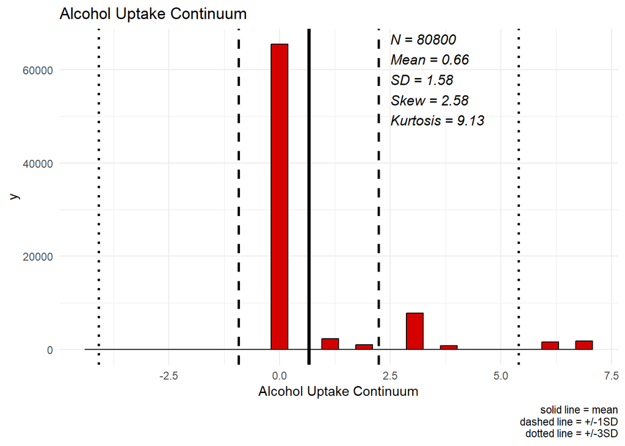

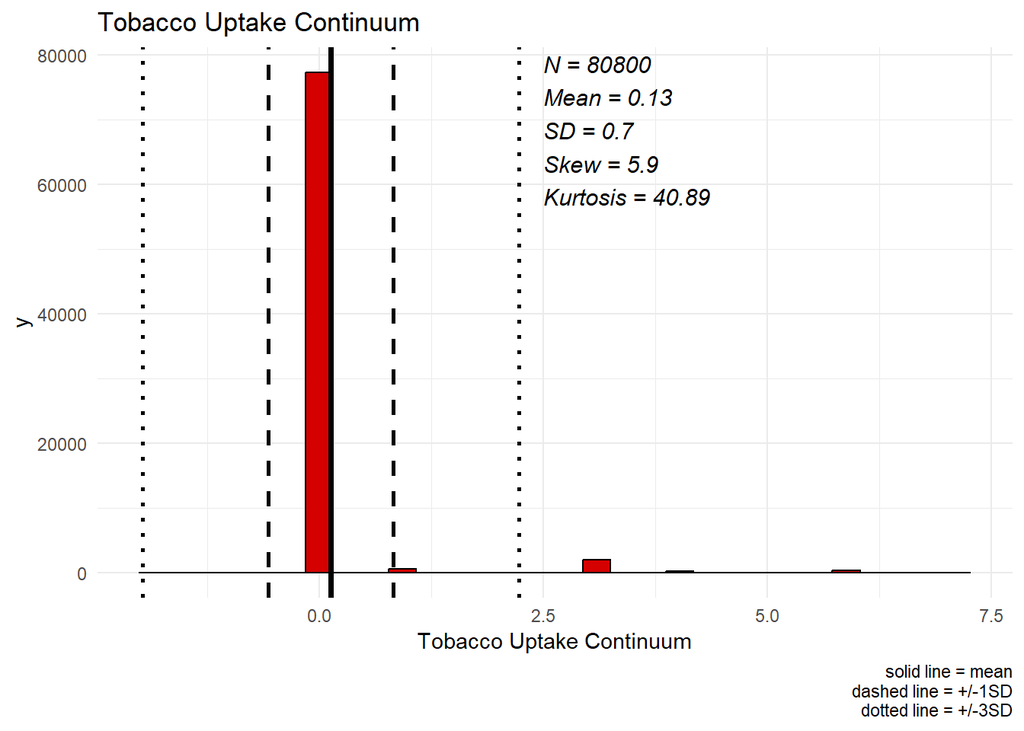

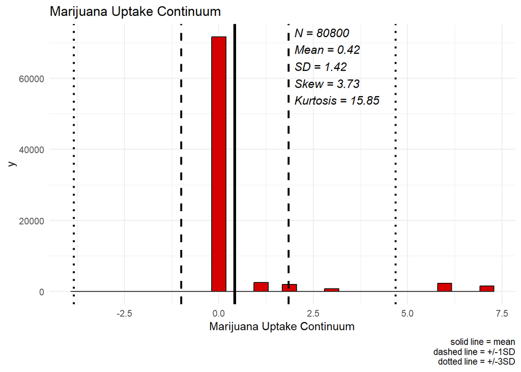

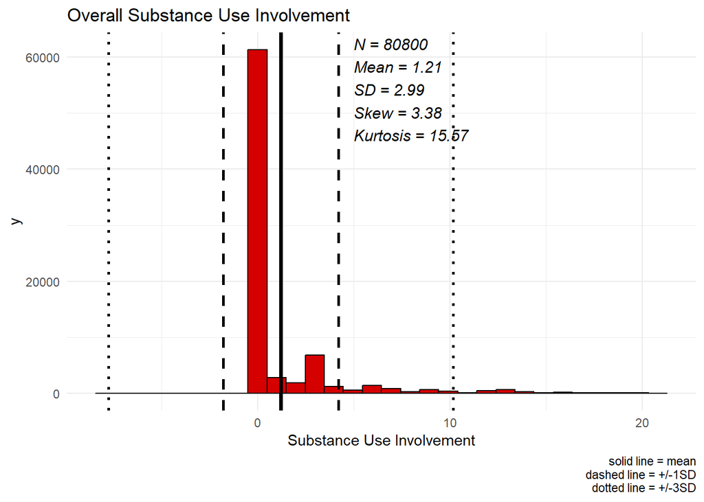